# Nut and fruit trees

Malcolm Ross

## 1. Introduction

Arboriculture apparently played a role in Bismarcks food production long before the arrival of Austronesian speakers and the latter quite possibly acquired some of their arboriculture practices from Papuan speaking neighbours (chapter 2, §4). With the introduction of agriculture, garden and forest tended to overlap. Sometimes the garden would include food-bearing trees that survived from the primary forest, and sometimes food-bearing species would be planted in a garden or orchard or near to the village. At the same time, forest trees continued to be tended in situ and came to be owned by particular families.

Kennedy & Clarke (2004) and others have emphasised the cline that ranges from trees which grow wild in the bush to trees that are cultivated in orchards, with various degrees of tree-tending between the two extremes. Continuous cultivation entails domestication, i.e. ongoing control of reproduction and selection of varieties through the planting of ripe fruits or germinated seeds or through the transplanting of vigorous seedlings (Yen 1991). The resulting cultivars often have separate local names, whereas forest varieties generally do not. Walter & Sam (2002: 73-74) suggest that the geographic distribution of domesticated tree species reflects human settlement in the Pacific. As domesticated species they list the following: canarium nuts, *Canarium* spp., the Tahitian chestnut, *Inocarpus fagifer*, cutnuts, *Barringtonia edulis*, *Barringtonia novae-hiberniae* and *Barringtonia procera*, the Polynesian plum, alias golden apple, *Spondias cytherea*, the island lychee, *Pometia pinnata*, and the Malay apple, *Syzygium malaccense*. To this list Mueller-Dombois & Fosberg (1998: 56-57) add the dragon plum, *Dracontomelon vitiense* and Yen (1991) adds *Burckella obovata*. Paijmans (1976: 123-124) notes that in the New Guinea region *Terminalia catappa* and *Terminalia kaernbachii* are also often planted.

All are actively cultivated close to villages and have been subject to continuous selection. Often they grow interspersed with coconut palms and breadfruit trees (themselves both domesticated species) on a piece of land close to the village, along with recently introduced citrus species. Actual tending is minimal; young seedlings are protected from the sun, weeds are removed, dead or damaged branches are cut off and the tree is sometimes pruned to reduce its height (Walter & Sam 2002: 74–76).

The remainder of this chapter is organised as follows. First, domesticated nut trees are treated (§2), then domesticated fruit trees (§3), and finally trees that are regularly exploited for their fruit but are generally not domesticated (§4). The boundary around this last category is somewhat arbitrary. It includes trees which are often mentioned in the literature as sources of edible fruit. It excludes trees that are more often mentioned as having other uses: these include *Morinda citrifolia*, and various species of *Diospyros*, *Macaranga* and *Garcinia*, the fruits of which are all mentioned by Paijmans (1976: 124) as occasionally consumed. It also excludes those species of *Ficus* which have edible figs, as these are treated in ch.10, §4.

The trees investigated by Kennedy & Clarke (2004) in their examination of arboriculture include three that are considered among the staple foods in chapter 9: the banana plant (ch.9, §3), the breadfuit tree (ch.9, §4), and the sago palm (ch.9, §5.1). Another cultivated tree is *Gnetum gnemon*, the leaves of which serve as a green vegetable, treated in chapter 10, §2.3. These trees and plants are not considered further here, nor is the coconut palm, which is discussed in some detail in chapter 12. Instead, the focus of this chapter is nut- and fruit-bearing species that loom large in Bismarcks arboriculture.

## 2. Domesticated nut trees

### 2.1. *Canarium* spp. (Burseraceae)

*Canarium* is one of a suite of plants that were domesticated in the rain forests of northern New Guinea during the early Holocene. Other members of the suite were the breadfruit (*Artocarpus altilis*) and the two fruit trees *Pometia pinnata* and *Burckella obovata* (Yen 1996). *Canarium* is the most important nut-bearing genus in Papua New Guinea, cultivated by almost a third of the rural population (Bourke & Allen forthcoming).

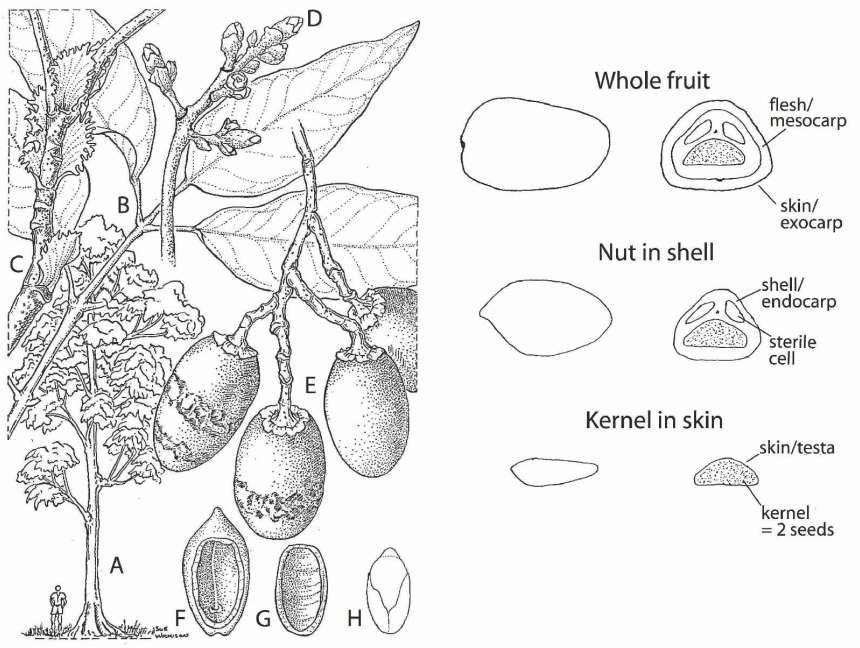

**Figure 11.1:** **Left** *Canarium indicum*: **A**, tree; **B**, portion of leaf showing terminal four leaflets; **C**, portion of branch showing large stipules (leaflike appendages at base of leaf stalk); **D**, immature inflorescence; **E**, cluster of fruit.; **F**, opened pericarp (exocarp + mesocarp + endocarp); **G**, opened shell/endocarp; **H**, edible kernel. **Right** Parts of the *Canarium indicum* fruit

*Canarium indicum* grows to a height of 15-30 m and in the wild is one of the smaller trees of the rain forest canopy. The fruit is a drupe with an oily edible kernel. The skin (exocarp) of the fruit is green when unripe, black when ripe. The ripe flesh (mesocarp) is edible but astringent and deteriorates rapidly. Inside the flesh is the shell (endocarp) and inside the shell is the edible kernel consisting usually of two seeds, each enclosed in its own skin (testa), which is peeled off before the seeds are eaten (Evans 1999: 6; see Figure 11.1).

Particular tree species display considerable variation in their forms, and this variation reflects the time depth of cultivation and domestication. Thus round fruit predominate in Vanuatu, oval fruit in the Solomons. Nuts may contain one kernel or two, which may be white or yellow. The rhythm of flowering, which can be altered by vigorous pruning, varies so that trees can be harvested at different times. *Canarium indicum* trees are usually individually owned and in some areas are tended where they have grown naturally in the forest. In the Solomons most are planted near villages. *Canarium salomonense* is usually a cultivated tree. Solomon Islanders consider *Canarium indicum* to require more light than *Canarium salomonense*, and hence more attention has to be paid to clearing other trees around it (Evans 1999: 40). Walter & Sam (2002: 153) report that in Vanuatu spontaneously germinated seedlings or fully ripened fruits are sometimes planted in gardens or villages.

*Canarium indicum* and *Canarium salomonense* are especially valued for their oily nuts and there is evidence that this was already true in POc times (ch.2, §4). *Canarium* nuts are broken open with a stone. Along the northeast coast of New Guinea, in the Bismarcks, in Bougainville and in the Solomons, their kernels are eaten raw or smoked, or the smoked nuts are pounded with sago, bananas or a root crop[^3]: to make an oily pudding (POc *puro-ŋ, ch.12, §4.2) (Paijmans 1976: 123-124, Peekel 1984:281, Bourke 1996, Kwa’ioloa&Burt2001: 102). A Takia speaker once described the pudding to me as ‘pork when there is no pig’: it is presented to honoured guests. Hviding (2005: 128, 133) says it is ‘a very important food, as much now as in the old days’ in Marovo, where traditionally the first puddings were presented to spirits. Similarly on Small Malaita and Ulawa there were ceremonies associated with the first nuts: on Small Malaita this occurred with the first harvest in early August, on Ulawa when the first smoked nuts are ready. In both cases a priest sacrificed nuts and pudding to the ancestors (Ivens 1927: 367-369). On Choiseul *Canarium salomonense* has been elevated to a high level of spiritual significance manifested in a variety of practices (McClatchey et al. 2006a ). The cultural importance of *Canarium* is seen in the Marovo term *buruburu* ‘*Canarium* spp. (generic)’, which is also used for ‘year’, the interval between two ripenings of canarium nuts (Hviding 2005: 107).

Among the Kwara’ae *Canarium* wood is regarded as unsuitable for building, as it becomes worm-eaten (Kwa’ioloa & Burt 2001: 103), but Powell (1976) reports that the Bola use it for canoe hulls and building materials. The Kwara’ae use its resin for caulking cracks in canoes.

*Canarium harveyi* is almost identical in appearance to *Canarium salomonense* and was earlier thought to be a variety of the latter. *Canarium salomonense* is dioecious, whereas *Canarium harveyi* is polygamodioecious, presumably as a result of selection (Evans 1999: 59). Both are similar in appearance to *Canarium indicum*.[^4]: The shell of a *Canarium salomonense* nut cracks into two halves when it is hammered, whereas the shell of *Canarium indicum* shatters. Both are processed and eaten in much the same ways (Record 1945; Kwa’ioloa & Burt 2001: 104).

Of the three terms reconstructed below, POc *[ka]ŋaRi was almost certainly the term for *Canarium indicum* as well as the generic term for *Canarium* species.[^5]:

Note that the initial syllable of *[ka]ŋaRi is reflected only in Admiralties, North New Guinea and Papuan Tip languages (and perhaps in Raga and Namakir), whereas Meso-Melanesian and Eastern Oceanic reflexes point to *ŋaRi. This distribution justifies the reconstruction of POc forms with and without initial *ka-, which may represent or have been reanalysed as the prefix *ka- ‘tree’ reflecting earlier *kayu ‘tree’ (ch.2, §7.1.2). Bola *taŋari* may reflect the addition of an otherwise unknown prefix *ta-* to *ŋaRi.

Marshallese *kaŋal* ‘*Pisonia grandis*’ looks as if it is a borrowing from a language retaining initial *ka-*, i.e. Admiralties or Western Oceanic, but on current knowledge of Oceanic settlement history it is difficult to see how this could have occurred.

| **PCEMP** |  | *ka(n,ŋ)aRi | ‘canarium almond, *Canarium* spp.’ |
| --- | --- | --- | --- |
| **POc** |  | *[ka]ŋaRi | ‘canarium almond, *Canarium indicum*’ |
| Adm | Lou | *kane* | ‘canarium almond’ |
| Adm | Titan | *aŋei* | ‘almond’ |
| Adm | Baluan | *kanai* | ‘canarium almond’ (Nevermann 1934) |
| Adm | Sori-Harengan | *kenai* | ‘canarium almond’ (Nevermann 1934) |
| Adm | Papitalai | *aŋei* | (glossed ‘almond’ by Nevermann 1934) |
| NNG | Kove | *aŋahi* | ‘canarium almond’ (A. Chowning, pers. comm.) |
| NNG | Lukep | *kaŋar* | ‘canarium almond’ |
| NNG | Mengen | *kaŋali* | ‘canarium almond’ |
| NNG | Takia | *aŋar* | ‘canarium almond’ |
| NNG | Manam | *kaŋari* | ‘canarium almond’ |
| PT | Muyuw | *kinay* | ‘canarium almond’ |
| MM | Bola | *taŋari* | ‘canarium almond, *Canarium indicum*’ (*t-* for expected †*k-*) |
| MM | East Kara | *ŋai* | ‘canarium almond, *Canarium indicum*’ |
| MM | Patpatar | *ŋar* | ‘canarium almond, *Canarium indicum*’ |
| MM | Uruava | *nari* | ‘canarium almond’ |
| MM | Vangunu | *ŋari* | ‘canarium almond’ |
| MM | Kusaghe | *ŋari* | ‘*Canarium indicum*’ (Evans 1999: 39) |
| **PEOc** |  | *[qa]ŋaRi | ‘canarium almond, *Canarium* spp.’ |
| SES | Bugotu | *ŋali* | ‘canarium almond’ (W. McClatchey, pers. comm.) |
| SES | Gela | *ŋali* | ‘canarium almond’ |
| SES | Kwara’ae | *ŋali* | ‘canarium almond’ |
| SES | Lau | *ŋali* | ‘canarium almond’ |
| NCV | Mwotlap | *na-ŋey* | ‘canarium almond’ |
| NCV | Mota | *ŋai* | ‘canarium almond’ |
| NCV | Ambae | *ŋai* | ‘canarium almond’ |
| NCV | Araki | *ŋa-ŋa* | ‘canarium almond’ |
| NCV | Raga | *aŋai* | ‘native almond; kidney’ |
| NCV | Naman | *n-eŋe* | ‘canarium almond’ |
| NCV | Nese | *n-eŋa* | ‘canarium almond’ |
| NCV | Port Sandwich | *ni-ŋai* | ‘canarium almond’ |
| NCV | Paamese | *iŋā* | ‘canarium almond’ |
| NCV | Lewo | *(pur)ŋi* | ‘canarium almond’ |
| NCV | Namakir | *ʔaŋa* | ‘canarium almond’ |
| NCV | Nguna | *na-ŋai* | ‘canarium almond’ |
| NCV | South Efate | *na-ŋe* | ‘canarium almond’ |
| SV | Sye | *na-ŋai* | ‘canarium almond’ |
| SV | Lenakel | *na-ŋe* | ‘canarium almond’ |
| SV | Anejom̃ | *na-ŋai* | ‘canarium almond’ |
| SV | Sye | *na-ŋai* | ‘canarium almond’ |

cf. also:

| Mic | Marshallese | *kaŋal* | ‘*Pisonia grandis*’ |
| --- | --- | --- | --- |

| **PWOc** |  | *pinuaq | ‘a nut tree, perhaps *Canarium* sp. (?)’ |
| --- | --- | --- | --- |
| PT | Lala | *viŋu* | ‘*Terminalia catappa*’ |
| MM | Patpatar | *hinuai* | ‘canarium almond, *Canarium indicum*’ |
| MM | Bilur | *inuai* | ‘canarium almond’ |
| MM | Kandas | *nui* | ‘canarium almond’ |
| MM | Tinputz | *winoa* | ‘canarium almond’ |
| MM | Kia | *finua* | ‘*Canarium salomonensis*’ (W. McClatchey, pers. comm.) |

| **POc** |  | *(q)alipa, *lalipa | ‘nut sp., possibly canarium almond, *Canarium* sp.’ (?) |
| --- | --- | --- | --- |
| Adm | Drehet | *n-elip* | ‘k tree: nut, grows wild, very hard skin, oval, about one centimetre long, dark green’ (perhaps *Canarium chinare*; J. Kennedy, pers. comm.) |
| NNG | Mangap | *lelivii* | ‘*Terminalia catappa*’ |
| NNG | Dami | *lali* | ‘canarium almond’ |
| NNG | Tami | *yalip* | ‘canarium almond’ |
| NNG | Numbami | *yalipa* | ‘canarium almond’ |
| NNG | Yabem | *lanip* | ‘canarium almond’ |
| NNG | Kaiwa | *lalip* | ‘canarium almond’ |
| NNG | Kairiru | *laliu* | ‘big, red canarium almond’ |
| NNG | Ulau-Suain | *liliu* | ‘canarium almond’ |
| MM | Minigir | *galip* | ‘canarium almond’ |
| MM | Tolai | *galipa* | ‘canarium almond’ |
| SES | Kwara’ae | *(ʔai)lali* | ‘Tahitian chestnut, *Inocarpus fagifer*’ (lit. ‘kidney tree’) |

Kwa’ioloa and Burt (2001: 119) note that Kwara’ae *lali* is also used for ‘kidney’. However, the semantic extension is from ‘nut’ to ‘kidney’, not vice versa, as the use of ‘nut’ words for kidneys is quite common, e.g. Arosi *kora i mabʷe* ‘kidneys’ (lit. ‘fruit of Tahitian chestnut’ ), Niuean *fua-ifi* ‘kidney’ (lit. ‘fruit of Tahitian chestnut’).

### 2.2. *Inocarpus fagifer*, Tahitian chestnut, Pacific chestnut, Polynesian chestnut, TP *aila*, B *namambe* (Fabaceae)

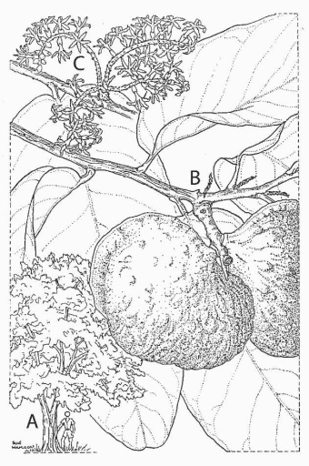

**Figure 11.2:** *Inocarpus fagifer*, Tahitian chestnut: **A**, tree; **B**, portion of branch bearing fruit; **C**, inflorescence.

*Inocarpus fagifer* is a common second storey tree of the foreshore or lowland forest, reaching 15-30 m in height in the Bismarcks but shorter on islands further east. Its trunk is straight and fluted (Figure 11.2). Its fruit is a pod about 8cm long which does not release its single white seed, which must be cooked to be palatable. The enormous variety of its forms reflects the fact that it has long been cultivated (Bourke & Allen (forthcoming) report that it is cultivated by a sixth of Papua New Guinea’s rural population). Leaves may be elongated and narrow or oblong and wide. The fruit may be rounded, crescent-shaped or elongated-oval and green, brown or yellow (Walter & Sam2002: 183-184). Right across Oceania it is either boiled or roasted like a chestnut (Paijmans 1976: 124, Evans 1999: 19-21, S. Foale 2001, Walter & Sam 2002: 183, Gardner & Pawley 2006). Hence the English term ‘Tahitian chestnut’. It is then either eaten without further treatment, or in the Solomons and Fiji grated on coral and made into bread or pudding (Capell 1941, Peekel 1984: 245, Evans 1999: 19, Walter & Sam 2002: 185). In parts of Vanuatu it is a major alternative food between the two yam seasons, and the nuts are stored in various ways (Walter & Sam 2002: 185).

The cooked seed varies in taste and villagers choose trees according to the taste of their seeds. The tree spreads naturally and prolifically and is then often carefully protected. Seedlings that grow around the base of the trunk are left in place if the tree is little used, but removed from others so that fallen fruit can be harvested more easily. In Vanuatu seedlings of trees bearing fruit preferred by villagers are transplanted close to the village, but this seems to occur less commonly in the Solomons (Walter & Sam 2002: 184–185).

On Lihir the leaves of *Inocarpus fagifer* are used to parcel up food for cooking in a stone oven (S. Foale 2001). The wood is brittle and susceptible to borers and in general little used, but in Fiji and Tonga tool handles are made from the flutes of its trunk (Walter & Sam 2002: 186, Gardner & Pawley 2006).

Blust (ACD) argues that Dempwolff (1938) confused reflexes of POc *qipil ‘ironwood, *Intsia bijuga*’ (ch.7, 4.9) with those of POc *ipi ‘Tahitian chestnut, *Inocarpus fagifer*’. The difference between the two denotata, he suggests, justifies separate reconstructions. He is certainly right, as Marovo has distinct reflexes of the two terms, respectively *kivili* and *ivi*.[^7]:

| **POc** |  | *ipi | ‘Tahitian chestnut, *Inocarpus fagifer*’ |
| --- | --- | --- | --- |
| Adm | Mussau | *ii* | ‘Tahitian chestnut’ |
| NNG | Amara | *(e)ip* | ‘Tahitian chestnut, *Inocarpus fagifer*’ |
| NNG | Lukep | *ip* | ‘nut-bearing tree’ |
| NNG | Gitua | *ipi* | ‘Tahitian chestnut’ |
| NNG | Bing | *yip* | ‘Tahitian chestnut’ |
| NNG | Takia | *ip* | ‘Tahitian chestnut’ |
| PT | Bwaidoga | *ɣivi* | ‘wild chestnut’ |
| MM | Simbo | *ivi* | ‘Tahitian chestnut’ |
| MM | Nduke | *ivi* | ‘Tahitian chestnut’ |
| MM | Marovo | *ivi* | ‘Tahitian chestnut’ |
| MM | Gao | *na-efi* | ‘Tahitian chestnut, *Inocarpus fagifer*’ (W. McClatchey, pers. comm.) |
| MM | Maringe | *na-ifi* | ‘Tahitian chestnut, *Inocarpus fagifer*’ (W. McClatchey, pers. comm.) |
| **PEOc** |  | *ipi | ‘Tahitian chestnut, *Inocarpus fagifer*’ |
| Mic | Kiribati | *ibi* | ‘Tahitian chestnut’ |
| Fij | Bauan | *ivi* | ‘Tahitian chestnut’ |
| Fij | Wayan | *ivi* | ‘Tahitian chestnut’ |
| Fij | Rotuman | *ʔifi* | ‘Tahitian chestnut’ |
| Pn | Tongan | *ifi* | ‘Tahitian chestnut, *Inocarpus fagifer*’ |
| Pn | Anutan | *ipi* | ‘Tahitian chestnut’ |
| Pn | Samoan | *ifi* | ‘Tahitian chestnut, *Inocarpus fagifer*’ |
| Pn | Rarotongan | *iʔi* | ‘Tahitian chestnut’ |

| **PEOc** |  | *mabʷe | ‘Tahitian chestnut, *Inocarpus fagifer*’ (Lynch 2004a; Chowning 2001: *m(ʷ)ap(ʷ)e) |
| --- | --- | --- | --- |
| SES | Sa’a | *mapʷe* | ‘Tahitian chestnut’ |
| SES | Santa Ana | *mʷapʷe* | ‘Tahitian chestnut’ |
| SES | Kahua | *mabe* | ‘Tahitian chestnut’ (Henderson and Hancock 1988) |
| NCV | Mota | *mabʷe* | ‘tree sp.’ |
| NCV | Ambae | *magʷe* | ‘Tahitian chestnut’ |
| NCV | Nokuku | *mape* | ‘Tahitian chestnut’ |
| NCV | Kiai | *mape* | ‘Tahitian chestnut’ |
| NCV | Tamambo | *(vu)mabue* | ‘Tahitian chestnut’ |
| NCV | Araki | *uetᫀe* | ‘Tahitian chestnut’ |
| NCV | Raga | *mʷabʷe* | ‘tree sp.’ |
| NCV | Nese | *na-mab* | ‘Tahitian chestnut’ |
| NCV | Port Sandwich | *na-mbʷe* | ‘Tahitian chestnut’ |
| NCV | Namakir | *mʷamʷ* | ‘Tahitian chestnut’ |
| NCV | Nguna | *na-mʷapʷe* | ‘Tahitian chestnut’ |
| SV | Anejom̃ | *n-mapʷ* | ‘Tahitian chestnut’ (Wheatley 1992: 143) |
| Pn | Rapanui | *mape* | ‘kidney’ |
| Pn | Mangarevan | *mape* | ‘local chestnut’ |
| Pn | Pukapukan | *mape* | ‘ovary’ |
| Pn | Tahitian | *māpē* | ‘kidney; *Inocarpus fagifer*’ |

Ivens (1929) assumes that Sa’a (SES) *mapʷe* ‘*Inocarpus fagifer*’ is a borrowing from Mota, but this supposition seems unnecessary.

The Tahitian reflex above is glossed ‘kidney’ as well as ‘*Inocarpus fagifer*’, and the Rapanui reflex denotes only ‘kidney’. As noted in §2.1, there is a tendency for names of nuts also to be used as (or as part of) the term for the kidney.

### 2.3. *Barringtonia* spp. other than *Barringtonia asiatica*, cutnut, bush nut, TP *pao*, B *navele* (Lecythidaceae)

Peekel (1984: 397) says that the seeds of *Barringtonia novae-hiberniae* are superior to those of *Barringtonia procera*. Otherwise the three species are very similar and are sometimes confused in botanical reports. Jebb (1992) provides a careful and relatively recent study of the edible species, and the synonyms above are based on his listing. There are numerous cultivars, and this has led to the proliferation of synonyms as well as confusions about which species a given cultivar represents. Evans (1999: 38) comments that in indigenous Solomons taxonomies *Barringtonia edulis* is often classified with *Barringtonia novae-hiberniae*.

Of the three species, it seems probable that only *Barringtonia novae-hiberniae* was present in the Bismarcks in early Oceanic times, although, like *Barringtonia edulis*, it is only a minor food source in present-day Papua New Guinea. It is the only species of the three which grows wild in the forests of Papua New Guinea (Jebb 1992), and it is also the species which Peekel (1984: 397) reports as being tended or planted in gardens and around villages in New Ireland for its edible seeds.

All three species grow wild in the forests of the Solomon Islands, often in wet places. *Barringtonia novae-hiberniae* is more likely to grow wild (it is considered to be the most shade-tolerant of the three species), whilst *Barringtonia procera* and *Barringtonia edulis* are more likely to grow near villages where they are often transplanted to groves along with *Canarium* trees (Evans 1999:40-41, Hviding 2005: 146).

Jebb (1992) reports that wild specimens of *Barringtonia procera* have only been found in the Solomons. Cultivated varieties of *Barringtonia procera* abound in the Solomons and Vanuatu, suggesting that it has long been domesticated there (Walter & Sam 2002: 118). Indeed, local informants told Yen (1996) that *Barringtonia procera* originated on Santa Cruz Island in the extreme east of the Solomons, and he appears to entertain this possibility. Thus it seems to have been transported from the Solomons and Bougainville to New Ireland and thence to the Gazelle Peninsula of New Britain and the Admiralties (Bourke 1996), perhaps in the last thousand years. The fact that it had not spread to the rest of New Britain or to New Guinea by 1870 suggests that its spread occurred later rather than earlier.[^9]: J. Kennedy’s (pers. comm.) informants in the Admiralties regard *Barringtonia procera* as old there, and Bourke (forthcoming) regards it as a pre-contact introduction. If this reconstruction of events is correct, then it may be that *Barringtonia procera* displaced earlier *Barringtonia novae-hiberniae* cultivation in the Bismarcks.[^10]:

Peekel apparently did not find *Barringtonia edulis* in New Ireland during his work, which predated the second World War. On the other hand, in Fiji it is the only edible *Barringtonia* species and grows wild in both open and dense forest (it is rarely cultivated there; Jebb 1992). It also grows in the wild and occurs in many varieties in the Solomons and Vanuatu, indicating a long cultivation history (Walter & Sam 2002: 112-113). These facts suggest that *Barringtonia edulis* may have been brought to the Bismarcks very recently.

These considerations influence the interpretation and glossing of the reconstructions below. Only one POc term, *pala(ŋ), can be convincingly reconstructed for edible *Barringtonia*, and it is a reasonable inference that it denoted *Barringtonia novae-hiberniae*. Peekel reports two varieties in New Ireland: the more desirable variety has fruit ‘blackish-purple to wine-red’, the other pale green. In Patpatar, the red variety is called *paua kubar*, the green *paua pala*.[^11]: It is thus possible that POc *pala(ŋ) denoted the green variety.

The final *-(ŋ) is added on the basis of Kara *falaŋ*. However, the absence of a reflex in other Meso-Melanesian languages, where a final-consonant reflex is expected, makes its reconstruction doubtful.

| **POc** |  | *pala(ŋ) | ‘cut nut, bush nut, *Barringtonia novae-hiberniae* (green variety?)’ |
| --- | --- | --- | --- |
| MM | East Kara | *faləŋ* | ‘*Barringtonia novae-hiberniae*’ |
| MM | Patpatar | *(paua) pala* | ‘*Barringtonia novae-hiberniae*, variety with pale green fruit’ |
| MM | Kokota | *fala* | ‘cut nut’ |
| MM | Gao | *fala* | ‘*Barringtonia edulis*’ (W. McClatchey, pers. comm.) |
| MM | Maringe | *fala* | ‘*Barringtonia procera*, cut nut’ (Evans 1999: 39) |
| TM | Tanibili | *no-volo* | ‘cut nut’ |
| TM | Tanema | *vara* | ‘cut nut’ (*-r-* for †*-l-*) |

| **PEOc** |  | *pala | ‘cut nut, bush nut, *Barringtonia* sp .’ |
| --- | --- | --- | --- |
| SES | Talise | *vala* | ‘cut nut’ |
| SES | Kwara’ae | *fala* | ‘*Barringtonia procera*, *Barringtonia edulis*, *Barringtonia novae-hiberniae*’ (W. McClatchey, pers. comm.) |
| SES | Arosi | *hara* | ‘*Barringtonia edulis*’ |
| SES | Bauro | *hara* | ‘cut nut’ |
| SES | Kahua | *hara* | ‘cut nut’ |
| NCal | Nyelâyu | *pālac* | ‘*Barringtonia* neocaledonica’ |
| Fij | Wayan | *(kutu)vala* | ‘*Barringtonia edulis*, with large seed edible raw or cooked’ |

Also seemingly reconstructable on the basis of the cognate set below is POc *pele, but the fact that it differs from POc *pala(ŋ) only in its vowels suggests that some or all of the terms in the set reflect borrowings associated with the westward expansion of either *Barringtonia procera* or *Barringtonia edulis*. Additionally problematic are the fact that the two terms found in New Britain (Nakanai, Meramera *uele*) denote other nut trees and not a *Barringtonia* sp., and the fact that they reflect POc initial *w- rather than *p-.

| MM | Nakanai | *uele* | ‘*Canarium mehenbethene*’(Floyd 1954) |
| --- | --- | --- | --- |
| MM | Meramera | *uele* | ‘Tahitian chestnut’ |
| MM | Vaghua | *vele* | ‘cut nut’ |
| MM | Babatana | *vele* | ‘*Barringtonia procera*, *Barringtonia edulis*, *Barringtonia novae-hiberniae*’ (W. McClatchey, pers. comm.) |
| NCV | Mota | *vele* | ‘*Barringtonia edulis*’ |
| NCV | Tamambo | *(vu)vale* | ‘*Barringtonia edulis*’ |
| NCV | Raga | *vele* | ‘*Barringtonia edulis*’ |
| NCV | Apma | *vʷel* | ‘*Barringtonia edulis*’ |
| NCV | Lonwolwol | *woleh* | ‘a common edible nut’ |
| NCV | Namakir | *vil* | ‘*Barringtonia edulis*’ |
| NCV | Nguna | *na-vīla* | ‘*Barringtonia edulis*’ |
| SV | Sye | *vel(ŋah)* | ‘*Barringtonia edulis*’ |
| SV | Ura | *ni-ver(ŋi)* | ‘*Barringtonia edulis*’ |

Although *kinu ‘edible *Barringtonia* species’ has reflexes in both Meso-Melanesian and SE Solomonic languages, the members of the set are spread across the border between Western and Eastern Oceanic, so borrowing is more probable than shared inheritance from POc.

| MM | Roviana | *kinu* | ‘*Barringtonia* sp., with edible nut’ |
| --- | --- | --- | --- |
| MM | Nduke | *kino* | ‘cut nut’ |
| MM | Hoava | *kinu* | ‘cut nut’ |
| MM | Kusaghe | *kinu* | ‘*Barringtonia procera*, cut nut’(Evans 1999: 39) |
| SES | Gela | *kinu* | ‘k shore tree with ed. fruit’ |
| SES | Lau | *kinu* | ‘cut nut, *Barringtonia edulis*’ |
| SES | Kwaio | *kinu* | ‘cut nut’ |
| SES | Kwara’ae | *kiun-kinu* | ‘cut nut, *Barringtonia edulis*’(Evans 1999: 39) |

### 2.4. *Terminalia* spp. (Combretaceae)

A number of *Terminalia* species have edible ‘nuts’, but only two are reported to be planted in NW Island Melanesia. They are *Terminalia catappa* (sea almond, Indian almond, Java almond, TP talis, P alite, B natavoa) and *Terminalia kaernbachii* (okari nut, B natalie).[^12]: *Terminalia catappa* is distributed from southern India to Polynesia, but *Terminalia kaernbachii* occurs indigenously only in New Guinea and the Bismarck Archipelago (Bourke 1996, Walter & Sam 2002: 260). Several other species with edible nuts occur in NW Island Melanesia but are only harvested from the wild (*Terminalia copelandii*, *Terminalia impediens*; Paijmans 1976: 123-124), and yet other species have fruits with edible flesh (_Terminalia megalocarpa__, syn. *T. solomonensis*, *T. lapalagon*). Several *Terminalia* species found indigenously in the Solomons provide good timber: *Terminalia brassii*, T. calamansanai and *Terminalia sepicana* (Evans 1999: 10–11).

*Terminalia kaernbachii* is more slender and has thinner branches than *Terminalia catappa*. It is also taller, growing to 20-40 m (Peekel 1984:403, Evans 1999: 41). Its fruit is the largest known among the Combretaceae and contains a large edible seed which ranges in weight from 1.5 to 10 g. Its distribution is quite different from the coastal *Terminalia catappa*. It prefers instead inland environments up to an altitude of 1100 m with a greater diurnal temperature range. Until recently its distribution in the Bismarcks was limited to the extreme west of New Britain and to Manus Island in the Admiralties (Walter & Sam 2002:260, Bourke & Allen forthcoming, pers. comm.). Unfortunately, *Terminalia kaernbachii* has received relatively little attention in the literature, partly perhaps because of its restricted distribution and partly because it is overshadowed by the better known and far more widespread *Terminalia catappa*.

The literature also attributes little importance to *Terminalia catappa*, but this reflects a decline in its consumption since European contact. In the Solomons and Fiji the nuts tend to be eaten raw as snacks and collected by children, but they are not (or no longer?) used in cooking. Paijmans (1976: 123-124) and R.M. Bourke (pers. comm.) report that it is often planted and is a common village shade tree in New Guinea and the Bismarcks. Walter & Sam (2002: 255) say that *Terminalia catappa* nuts are sometimes preserved by smoking in New Britain and Bougainville. The situation in Vanuatu is ambiguous. Walter & Sam (2002: 255) report that *Terminalia catappa* is largely spread by birds and bats, and little cultivated, but the fact that there are many varieties there may point to past selection through planting.

In Vanuatu and on Waya (Fiji) the wood of *Terminalia catappa* was carved. In Vanuatu it is also used for canoes and for the frameworks of buildings (Walter & Sam 2002:255-256, Gardner & Pawley 2006). In Marovo juice squeezed from the leaves makes a medicine against various pains including toothache. Bark scrapings wrapped in leaves and heated over a fire are squeezed to produce a liquid given to children who have a sore throat, cough or diarrhoea, and it has similar uses in Vanuatu (Walter & Sam 2002:256, Hviding 2005: 145).

Comments in the agronomic literature about the relative insignificance of *Terminalia catappa* are belied by the fact that there is a term with very widespread reflexes, namely POc *talise. The denotatum of reflexes from New Guinea and the Bismarcks is usually noted simply as ‘*Terminalia* sp.’, but it is a reasonable inference that reflexes from coastal locations in New Guinea, from New Britain and New Ireland and from small islands all denote *Terminalia catappa* (R.M. Bourke, pers. comm.) and that this was the denotatum of POc *talise. If this interpretation is correct, then no term for *Terminalia kaernbachii* is reconstructable on the basis of the available data.

| **PMP** |  | *talisay | ‘*Terminalia catappa*’ (Dempwolff 1938) |
| --- | --- | --- | --- |
| **POc** |  | *talise | ‘*Terminalia catappa*’ (Milke 1961) |
| Adm | Seimat | *talil* | ‘*Terminalia* sp.’ (Sorensen 1950) |
| Adm | Lou | *telit* | ‘*Terminalia* sp.’ |
| Adm | Loniu | *tɛlus* | ‘*Terminalia* sp.’ |
| Adm | Titan | *drilis* | ‘*Terminalia* sp.’ |
| NNG | Mengen | *talisi* | ‘*Terminalia catappa*’ |
| NNG | Kove | *talize* | ‘*Terminalia* sp.’ |
| NNG | Tami | *talit* | ‘*Terminalia* sp.’ |
| NNG | Kela | *tarik* | ‘*Terminalia* sp.’ |
| NNG | Takia | *tali* | ‘*Terminalia* sp.’ |
| NNG | Kairiru | *talis* | ‘*Terminalia* sp.’ |
| MM | Vitu | *taðile* | ‘*Terminalia* sp.’ (metathesis) |
| MM | Bola | *tarile* | ‘*Terminalia* sp.’ (metathesis) |
| MM | Lavongai | *talisa* | ‘*Terminalia* sp.’ |
| MM | Madak | *ralis* | ‘tree sp.’ |
| MM | Sursurunga | *talis* | ‘Indian chestnut’ |
| MM | Tolai | *tali* | ‘*Terminalia* sp.’ |
| MM | Ramoaaina | *təliə* | ‘*Terminalia* sp.’ |
| MM | Babatana | *talike* | ‘*Terminalia catappa*’ (*-k-* for †*-∅-*) |
| MM | Nduke | *ta-talise* | ‘*Terminalia catappa*’ |
| MM | Roviana | *ta-talise* | ‘*Terminalia catappa*’ |
| MM | Marovo | *talise* | ‘*Terminalia catappa*’ |
| MM | Kia | *(na)klihe* | ‘*Terminalia catappa*’ (W. McClatchey, pers. comm.) |
| MM | Maringe | *(na)klise* | ‘*Terminalia catappa*’ |
| **PEOc** |  | *talise | ‘*Terminalia catappa*’ |
| SES | Gela | *talihe* | ‘*Terminalia catappa*’ |
| SES | Lau | *alite* | ‘*Terminalia catappa*’ |
| SES | Kwara’ae | *alita* | ‘*Terminalia catappa*’ |
| NCV | Mwotlap | *t[ı]lıs* | ‘*Terminalia catappa*’ |
| NCV | Mota | *salite* | ‘*Terminalia catappa*’ (metathesis) |
| NCV | Tolomako | *na-talise* | ‘*Inocarpus fagifer*’ |
| NCV | Apma | *telis* | ‘*Terminalia catappa*’ |
| NCV | Nguna | *na-talie* | ‘*Terminalia catappa*’ |
| NCV | South Efate | *n-tali* | ‘*Terminalia catappa*’ |
| **PSV** |  | *nə-talis | ‘*Terminalia catappa*’ (Lynch 2001c) |
| SV | Sye | *nteli* | ‘*Terminalia catappa*’ |
| SV | Lenakel | *telh* | ‘k.o. tree with flattish oval brown fruit which is cracked open and eaten’ |
| SV | Anejom̃ | *n-tejeθ* | ‘*Terminalia catappa*’ |
| **PCP** |  | *talise | ‘*Terminalia catappa*’ |
| Fij | Bauan | *daliði* | ‘*Terminalia catappa*’ |
| Pn | Tongan | *telie* | ‘*Terminalia catappa*’ |
| Pn | Niuean | *telie* | ‘*Terminalia catappa*’ |
| Pn | East Futunan | *talie* | ‘*Terminalia catappa*’ |
| Pn | Samoan | *talie* | ‘*Terminalia catappa*’ |
| Pn | Luangiua | *talie* | ‘tree sp. with big yellow berries’ |
| Pn | Marquesan | *taʔie* | ‘*Terminalia catappa*’ |
| Pn | Rarotongan | *taria* | ‘*Terminalia catappa*’ |
| Pn | Rennellese | *tagie* | ‘*Terminalia catappa*’ |
| Pn | Tokelauan | *talie* | ‘*Terminalia catappa*’ |

Two other POc terms possibly denoted *Terminalia* species: *tapoRa and *qatV. The POc denotatum of *tapoRa is unclear. In PEOc it evidently denoted a species of *Terminalia*, possibly *Terminalia catappa*,[^13]: but the glosses of the Takia and Nehan reflexes make it impossible to determine its POc denotation.

| **POc** |  | *tapoRa | ‘a nut-bearing tree sp.’ (Geraghty 1990) |
| --- | --- | --- | --- |
| NNG | Takia | *tapal* | ‘nut tree, like *Canarium*, but less oily’[^14] |
| MM | Nehan | *tauol* | ‘*Inocarpus fagifer*’ (Glennon and Glennon 2005) |
| **PEOc** |  | *tapoRa | ‘*Terminalia* spp.’ (Geraghty 1990) |
| SES | Kwara’ae | *dafo* | ‘*Terminalia brassii*’ |
| NCV | Mwotlap | *na-twoy* | ‘*Albizia saman*’ |
| NCV | Mota | *tawora* | ‘*Albizia saman*’ |
| NCV | Ambae | *tavoa* | ‘*Terminalia catappa*’ |
| NCV | Tamambo | *(vu)tavoa* | ‘*Terminalia catappa*’ |
| NCV | Maewo | *tavoa* | ‘*Terminalia catappa*’ |
| NCV | Raga | *tavoa* | ‘*Terminalia catappa*’ |
| NCV | Uripiv | *dawo* | ‘*Terminalia catappa*’ |
| NCV | Nese | *tavo* | ‘*Terminalia catappa*’ |
| NCV | Port Sandwich | *ravo* | ‘*Terminalia catappa*’ |
| NCV | Lonwolwol | *tavoro* | ‘a fruit’ |
| NCV | Paamese | *hoai* | ‘*Terminalia catappa*’ |
| NCV | Lewo | *(puru)tawo* | ‘*Terminalia catappa*’ |
| NCV | Baki | *(bur)tavu* | ‘*Terminalia catappa*’ |
| NCV | Namakir | *tauwo, tawo* | ‘*Terminalia catappa*’ |
| Fij | Bauan | *tāvola* | ‘*Terminalia catappa*’[^15] |

The set below appears to reflect a POc *qatV. Superficially Nehan *kasasas* appears cognate, but it is at best a borrowed reflex. The expected Nehan reflex would be *ata: Nehan *k-* and *-s-* reflect POc *k and *s respectively. *Terminalia complanata* and *Terminalia sepicana* are both uncultivated edible species, the nuts of which are occasionally consumed as snacks, and so the gloss ‘*Terminalia* sp. with edible nut’ is well enough supported.

| **POc** |  | *qatV | ‘*Terminalia* sp. with edible nut’ |
| --- | --- | --- | --- |
| MM | Madak | *(var)ʔa* | ‘*Terminalia complanata*’ |
| NCV | South Efate | *n-at* | ‘*Terminalia sepicana* (eaten only by fruit bat)’ |
| Mic | Chuukese | *asas* | ‘*Terminalia catappa*’ |
| Mic | Carolinian | *asas* | ‘*Terminalia catappa*’ |

cf. also:

| MM | Nehan | *kasasas* | ‘*Terminalia samoensis*’ |
| --- | --- | --- | --- |

### 2.5. *Pandanus* spp., screw pines (Pandanaceae)

*Pandanus* trees are an easily recognised feature in the forests of NW Island Melanesia. All species have aerial roots and very large thick leaves. The leaves of some species serve on canoes as sails, awnings, deck-houses, bailers and in houses as roofing, mats and wall lining. Sewn leaves are used for rain capes. POc *qebal ‘pandanus mat’ is reconstructed in vol. 1, ch.4, §3.1. The fruits of all species are syncarps, compound fruits with many segments, each a drupe, arranged around a core, and the fruits and/or seeds of various species are a source of food. Recognition of the various species, however, is much more difficult, partly because of intra-species variability which is at least partly the result of cultivation. Barrau (1962: 161-163) remarks that there is much confusion in the Linnaean naming of *Pandanus* species, and Henderson & Hancock (1988: 80, 232-236) do not provide names for the Solomons species they describe. Our sources are also often vague in their glosses of terms for pandanus types. Consequently it is possible that there are inaccuracies here. The four species for which POc terms can be reconstructed with reasonable certainty are:[^16]:

- *Pandanus tectorius*, the coastal pandanus: the most widespread and most exploited species throughout Oceania; its leaves are used for making mats;
- *Pandanus dubius*: it is widely distributed and remarkable for the size and strength of its leaves.
- *Pandanus conoideus*, with its long red or yellow fruit (Tok Pisin *marita*), a salient species in New Guinea but not common in the Bismarcks;
- *Pandanus lamekotensis*: seemingly restricted to the Admiralties and to northern and central New Ireland, but a POc term for it is reconstructable.

#### 2.5.1. *Pandanus tectorius* (syn. *Pandanus odoratissimus*), coastal pandanus (Pandanaceae)

*Pandanus tectorius* usually grows just behind the shore line to a height of 5-10 m. Its leaves are 1-2 m long, flat sheets tapering to a point. The orange fruit is made up of ‘fingers’ 6–8 em long, 4–5cm wide, each consisting of 8–17 parallel nuts (Figure 11.5, left). The species shows considerable variability, consistent with having been cultivated over a long period of time, and is often found near villages and old village sites (Peekel 1984:38, Walter & Sam 2002: 216–217). In NW Island Melanesia its use is patchy: it is used in Manus, the south coast of New Britain, in New Ireland and in Bougainville (Bourke n.d.).[^17]:

Selection has resulted in cultivars with thick but pliable leaves with edges free from spines, which serve as rain hoods and are used for making mats and baskets. In Vanuatu baskets are made from leaves softened in the fire, cut into narrow strips, steeped in water, then bleached and dried in the sun (Walter & Sam 2002: 216-217).

The alimentary use of *Pandanus tectorius* is less significant than uses of its leaves, but it is reported from Papua New Guinea, Vanuatu, Tonga and Samoa. The ripe globular fruit are sucked to obtain a sweet juice, perhaps more by children than by adults. This practice may have been far more common in the past, before the arrival of sweetened soft drinks (Walter & Sam 2002:217, Bourke n.d.). On Waya (Fiji) the juice was famine food (Gardner & Pawley 2006). Barrau (1962: 88) reports that the ends of the aerial roots are baked and eaten in some Micronesian and Polynesian societies, especially in atoll communities, where its fruits are also an important food source.

On Waya the trunks are used for house rafters and leaves for thatching (Gardner & Pawley 2006).

POc *padran appears to have specifically denoted *Pandanus tectorius*, but was evidently also used as a generic for pandanus species. POc *kiRe and *poipoi probably denoted only *Pandanus tectorius* or perhaps certain cultivars of *Pandanus tectorius*.

| **PAn** |  | *paŋudaL | ‘pandanus’ (Blust 1982) |
| --- | --- | --- | --- |
| **PMP** |  | *pandan | ‘pandanus’ (Dempwolff 1938) |
| **POc** |  | *padran | ‘coastal pandanus, *Pandanus tectorius*; pandanus (generic)’ (Biggs 1965: *para) |
| Adm | Mussau | *arana* | ‘littoral pandanus the leaves of which are used in plaiting mats and baskets, *Pandanus tectorius*’ |
| Adm | Leipon | *padr* | ‘kind of pandanus with narrow light-green leaves, used in plaiting mats’ |
| Adm | Lou | *par* | ‘pandanus’ |
| Adm | Titan | *par* | ‘pandanus fruit’ (Bowern 1999) |
| NNG | Amara | *(a)pada-pada* | ‘pandanus sp. with succulent fruit’ |
| NNG | Mangap | *pāⁿda* | ‘pandanus tree’ |
| NNG | Lukep | *pada* | ‘pandanus sp.’ |
| NNG | Malai | *padan* | ‘pandanus’ |
| MM | Lavongai | *aran* | ‘pandanus’ |
| MM | East Kara | *foran* | ‘*Pandanus tectorius*’ |
| MM | Kokota | *(i)fra* | ‘pandanus variety, small, used for making mats’ |
| TM | Tanema | *vadane* | ‘pandanus’ |
| SES | Lau | *fada-da* | ‘pandanus’ |
| NCV | Mota | *vana* | ‘a pandanus, inedible variety of female *Pandanus odoratissimus*’ |
| NCV | Lakon | *vac* | ‘*Pandanus tectorius*’ (François 2004b) |
| NCV | Vera’a | *vada* | ‘*Pandanus tectorius*’ (François 2004b) |
| NCV | Sakao | *ne-vor* | ‘*Pandanus cominsii*’ |
| SV | Kwamera | *nə-fara* | ‘pandanus’ |
| NCal | Jawe | *wan* | ‘coastal pandanus’ |
| NCal | Nyelâyu | *pān* | ‘coastal pandanus’ |
| Mic | Puluwatese | *fār* | ‘pandanus, used for mats and thatch’ |
| Mic | Carolinian | *fāṣa* | ‘pandanus (generic)’ |
| Fij | Wayan | *vadra* | ‘*Pandanus tectorius*’ |
| Pn | Tongan | *fā* | ‘taxon of several *Pandanus* spp.’ (Whistler 1991b: 24) |
| Pn | Hawaiian | *hala* | ‘*Pandanus tectorius*’ |

| **PMP** |  | *kiRay | ‘*Pandanus* sp.’[^18] |
| --- | --- | --- | --- |
| **POc** |  | *kiRe | ‘coastal *Pandanus* sp., probably *Pandanus tectorius*’ (French-Wright 1983) |
| PT | Gapapaiwa | *kire* | ‘mat made of sewn pandanus leaves’ |
| PT | Motu | *gere-gere* | ‘*Pandanus tectorius*’ |
| SES | Arosi | *gire* | ‘*Pandanus tectorius*’ |
| NCV | Mota | *gire* | ‘*Pandanus tectorius*’ |
| NCV | Mwotlap | *ne-gey* | ‘*Pandanus tectorius*’ (François 2004b) |
| NCV | Mwesen | *ger* | ‘*Pandanus tectorius*’ (Walter and Sam 2002) |
| NCV | Vurës | *(wö)gœr* | ‘*Pandanus tectorius*’ (François 2004b) |
| NCV | Raga | *gire* | ‘native tree with fruit like pineapple; pandanus’ |
| NCV | Tamambo | *hire-hire* | ‘woven container from coconut leaf’ |
| NCV | Big Nambas | *na-hei* | ‘mat’ |
| NCV | Nguna | *na-kie* | ‘mat pandanus’ |
| Fij | Bauan | *kie-kie* | ‘*Pandanus* sp.’ |
| Pn | Tongan | *kie* | ‘a sterile variety of pandanus used for weaving mats’ (Whistler 1991b: 56) |
| Pn | Pukapukan | *kie* | ‘specially made mat sometimes used as sail’ |

| **POc** |  | *poipoi | ‘*Pandanus* sp., perhaps *Pandanus tectorius*’ |
| --- | --- | --- | --- |
| MM | Nakanai | *voivoi* | ‘*Pandanus* sp.’ |
| SES | West Guadalcanal | *voivoi* | ‘pandanus’ |
| NCV | Mwotlap | *wow* | ‘*Pandanus* sp.’ |
| NCV | Araki | *ðᫀeðᫀe* | ‘*Pandanus tectorius*’ |
| NCV | Apma | *wip* | ‘*Pandanus tectorius*’ |
| NCV | Uripiv | *waiw* | ‘general word for pandanus’ |
| NCV | Uripiv | *weiw(bur)* | ‘shore pandanus, has big leaves, unusable’ |
| NCV | Port Sandwich | *vaiv* | ‘pandanus; skirt’ |
| NCV | Paamese | *heiho* | ‘*Pandanus* sp.’ |
| NCV | Lewo | *(puru)vava* | ‘pandanus’ |
| NCV | Lewo | *vava* | ‘pandanus’ |
| NCV | Namakir | *vaiv* | ‘smooth pandanus’ |
| SV | Lenakel | *nu-vie* | ‘pandanus sp.’ |
| Fij | Bauan | *voivoi* | ‘*Pandanus thurstoni*’ |
| Fij | Wayan | *voivoi* | ‘cultivars of *Pandanus tectorius* and possibly of *Pandanus dubius* or *Pandanus whitmeeanus*’ |

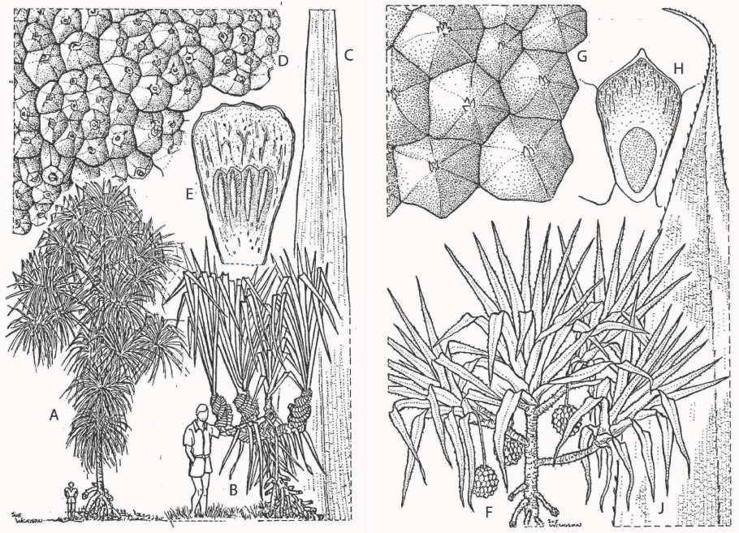

**Figure 11.5:** **Left** *Pandanus tectorius*: **A**, tree at its tallest; **B**, young plant when leaves harvested; **C**, end portion of leaf (no thorns); **D**, portion of surface of syncarp; **E**, longitudinal section of fruit segment. **Right** *Pandanus dubius*: **F**, tree, height 3m; **G**, syncarp from above; **H**, longitudinal section of fruit segment with edible kernel; **J**, leaf tip showing curved spike.

Lynch (2004a) suggests that the following set may also reflect POc *poipoi.

| **PSOc** |  | *va(i,y)u | ‘*Pandanus* sp.’ |
| --- | --- | --- | --- |
| NCV | Ambae | *ve-veo* | ‘*Pandanus* sp.’ |
| NCV | Tape | *na-viu* | ‘*Pandanus* sp.’ |
| NCV | Big Nambas | *ðᫀiu* | ‘*Pandanus* sp.’ |
| NCV | Nese | *na-ðᫀau* | ‘*Pandanus* sp.’ |
| NCV | Baki | *(buru)vewo* | ‘*Pandanus* sp.’ |
| **PSV** |  | *na-va(i,y)u | ‘*Pandanus* sp.’ (Lynch 2004a) |
| SV | Sye | *na-(ri)vyu* | ‘*Pandanus tectorius*’ |
| SV | Sye | *n-(or)veyu* | ‘bush pandanus’ |
| SV | Lenakel | *nu-vie* |  |

#### 2.5.2. *Pandanus dubius* (syn. *Pandanus compressus*) (Pandanaceae)

*Pandanus dubius* is a coastal species distributed from the Philippines southeastward as far as Vanuatu, where it is sometimes cultivated. It is the pandanus species with the broadest and stiffest leaves in the Bismarcks, 2 m or more in length and up to 16cm wide. The syncarps are made up of fingers 10-13cm long, 5-9cm wide, angular, but unlike other species not grooved (Figure 11.5, right)[^19]: (Peekel 1984: 41, Walter & Sam 2002: 212-213).

The fruiting spike is edible but rarely eaten, Sorensen (1950) reports for the Ninigos and Walter & Sam (2002: 212) for Vanuatu. The leaves are used for thatching, and with the spiny parts removed dried leaves are sewn together as mats and large baskets (Sorensen 1950, Peekel 1984: 41).

The POc term for *Pandanus dubius* was *pakum.[^20]:

| **POc** |  | *pakum | ‘*Pandanus dubius*’ (Peekel 1984: 41) |
| --- | --- | --- | --- |
| Adm | Mussau | *aum* | ‘broad-leafed pandanus, *Pandanus dubius*’ |
| Adm | Lou | *pɔk* | ‘pandanus’ |
| Adm | Titan | *pek* | ‘pandanus’ |
| NNG | Malai | *paum* | ‘pandanus’ |
| NNG | Takia | *wak* | ‘pandanus’ |
| NNG | Manam | *aku* | ‘pandanus (big leaf); used to make grass skirt’ |
| NNG | Bam | *wak* | ‘pandanus’ |
| NNG | Kairiru | *vʸak* | ‘*Pandanus dubius*’ |
| MM | East Kara | *faum* | ‘*Pandanus dubius*’ |
| MM | Patpatar | *hau* | ‘pandanus’ |
| MM | Tolai | *vaum* | ‘*Pandanus dubius*’ |
| MM | Sursurunga | *aum* | ‘tree type similiar to pandanus’ |
| SES | Kwara’ae | *faʔu* | ‘pandanus (generic); mat’ |
| SES | Kwaio | *faʔu* | ‘pandanus’ |
| NCV | Mota | *vau* | ‘a pandanus’ |
| NCV | Mwesen | *(wo)vag* | ‘*Pandanus dubius*’ (Walter and Sam 2002: 295) |
| NCV | Namakir | *na-vak* | ‘*Pandanus dubius*’ (Walter and Sam 2002: 295) |
| NCV | Nguna | *na-vaku* | ‘pandanus sp.’ |
| NCV | South Efate | *n-fak* | ‘*Pandanus dubius*’ |
| Pn | Tikopia | *fao* | ‘broad-leaved *Pandanus*, *Pandanus dubius*’ (possibly a borrowing from a SES language) |

#### 2.5.3. *Pandanus conoideus*, red fruit pandanus, TP marita (Pandanaceae)

*Pandanus conoideus* is a small tree, 4-7 m high, found in New Guinea, from the coasts up to an altitude of 2000 m.It is less common in the Bismarcks. It grows in damp, shady places around villages and on old village sites, and displays the variability typical of cultivation. Its trunk is covered in short sharp spikes, and the long leaves have spiked edges. Its syncarps are typically 20-40cm long, and sometimes reach 1 m and weigh as much as 10 kg. The fruit are bright red or occasionally yellow, and get their colour from the oil in the pericarp (Figure 11.6) (French 1986:210, Walter & Sam 2002: 210–211.)

The fruit are prized as a foodstuff and widely consumed. They are typically split, wrapped in leaves and cooked in an earth oven or roasted over a fire. The pulp and seeds are removed from the core, mashed with water and strained to produce a thick, rich red sauce with which other foods are seasoned (Sorensen 1950, Barrau 1962: 163, May 1984, Bourke in preparation).

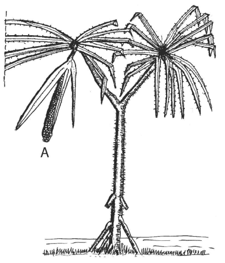

**Figure 11.6:** *Pandanus conoideus*, marita: **A**, syncarp.

POc *mʷafia apparently denoted *Pandanus conoideus*.[^21]: This reconstruction is open to doubt, as there are no reflexes from New Ireland or New Britain, where the species is rare, and only one from mainland New Guinea. It is possible that Maisin *moŋgi* ‘*Pandanus* sp.’ and PMic *maŋu ‘pandanus leaf’ are also cognate. If so, they reflect a POc form in which *-ñ- has been replaced by *-ŋ-.

Another interpretation of the data is also possible, namely that the items listed below, other than Arosi *mʷa-mʷana*, reflect POc *moñak ‘fat, oil, coconut cream; tasty’ (ch.12, §4.2), since the fruit of *Pandanus conoideus* are both oily and tasty. If this were so, then Arosi *mʷa-mʷana* and the items listed under ‘cf. also’ would probably reflect a PEOc *mʷaŋV ’pandanus leaf.

| **POc** |  | *mʷaña | ‘*Pandanus* sp., perhaps *Pandanus conoideus*’ |
| --- | --- | --- | --- |
| **PAdm** |  | *moña | ‘pandanus with long red or yellow fruit, probably *Pandanus conoideus*’ (Blust 1996b) |
| Adm | Seimat | *maun* | ‘*Pandanus conoideus*’ (*-o- > Seimat *-au-*) (Sorensen 1950) |
| Adm | Lou | *mon* | ‘*Pandanus conoideus*’ |
| Adm | Wuvulu | *mona* | ‘*Pandanus conoideus*’ |
| Adm | Likum | *mon* | ‘*Pandanus conoideus*’ |
| Adm | Nali | *mon* | ‘*Pandanus conoideus*’ |
| Adm | Pak | *mon* | ‘*Pandanus conoideus*’ |
| Adm | Lou | *mon* | ‘*Pandanus conoideus*’ |
| Adm | Leipon | *moñ* | ‘*Pandanus conoideus*’ |
| Adm | Loniu | *moñ* | ‘*Pandanus conoideus*’ |
| Adm | Bipi | *moy* | ‘*Pandanus conoideus*’ |
| Adm | Kele | *moy* | ‘*Pandanus conoideus*’ |
| Adm | Lenkau | *moy* | ‘*Pandanus conoideus*’ |
| Adm | Nauna | *moy* | ‘*Pandanus conoideus*’ |
| Adm | Drehet | *muŋ* | ‘*Pandanus conoideus*’ |
| NNG | Mapos Buang | *mon* | ‘*Pandanus conoideus*’ |
| SES | Arosi | *mʷa-mʷana* | ‘*Pandanus* sp., leaves plaited’ |

cf. also:

| PT | Maisin | *moŋgi* | ‘*Pandanus* sp.’[^22] |
| --- | --- | --- | --- |
| Mic | Kosraean | *mᵚeŋ* | ‘pandanus’ |
| Mic | Marshallese | *māŋ* | ‘pandanus leaves’ |
| Mic | Chuukese | *mə̄ŋ* | ‘pandanus leaf, especially when softened by a shell’ |
| Mic | Woleaian | *māŋü* | ‘pandanus leaf’ |

#### 2.5.4. *Pandanus lamekotensis* (Pandanaceae)

Peekel (1984: 41) remarks that *Pandanus lamekotensis* is readily distinguished from other species. However, I have otherwise found it mentioned only by Kennedy & Clarke (2004), who provide no additional information, and it is possible that its distribution is limited to New Ireland. Indeed, Peekel did not find it in the south of New Ireland or on the Gazelle Peninsula of New Britain. It grows only on swampy creek banks, 4–7 m high with from 5 to 8 leaves, and its fruit clusters are oval, not ‘fingers’. The ripe fruits, like those of *Pandanus tectorius* are sometimes sucked by New Ireland villagers.

| **POc** |  | *kaRi(q)ana | ‘*Pandanus lamekotensis*’ |
| --- | --- | --- | --- |
| Adm | Baluan | *kayaŋ* | ‘pandanus sp. similar to *Pandanus lamekotensis*’ |
| Adm | Nyindrou | *kayaŋ* | ‘*Pandanus* sp.’ |
| Adm | Bipi | *kaihan* | ‘*Pandanus* sp.’ |
| MM | East Kara | *kaiat* | ‘*Pandanus lamekotensis*’ (*-t* for †*-n*) |
| MM | Nalik | *kariat* | ‘*Pandanus lamekotensis*’ (*-t* for †*-n*) (Peekel 1984: 41) |
| MM | Madak | *[va]keiŋ* | ‘*Pandanus lamekotensis*’ |
| Mic | Kiribati | *kaina* | ‘*Pandanus tectorius*’ |

#### 2.5.5. Other names for *Pandanus* species

The four reconstructions below each denoted a species or a variety of *Pandanus*, but the glosses do not allow us to determine which.

| **PCEMP** |  | *ima | ‘*Pandanus* sp. with leaves useful for plaiting’ (ACD) |
| --- | --- | --- | --- |
| **POc** |  | *ima | ‘*Pandanus* sp. with useful leaves’ |
| NNG | Gedaged | *im* | ‘*Pandanus* sp.; has aerial roots, and its leaves are used to make rain capes’ |
| NNG | Kis | *im* | ‘bush pandanus’ |
| PT | Gapapaiwa | *imo(-kara)* | ‘bush pandanus’ |
| MM | Tangga | *im* | ‘tall shrub with many stalks, the leaves of which provide wrapping material for a corpse prior to burial’ |

| **POc** |  | *(p,pʷ)asa(r,R) | ‘large *Pandanus* sp.’ |
| --- | --- | --- | --- |
| Adm | Drehet | *pʷāh* | ‘large pandanus’ |
| PT | Misima | *pala* | ‘mat made: of pandanus’ |
| MM | Babatana | *(poro) basa* | ‘*Pandanus* sp.’ |
| MM | Maringe | *vahara* | ‘*Pandanus conoideus*’ (W. McClatchey, pers. comm.) |
| SES | Bugotu | *vaha* | ‘*Pandanus* aff. compressus martalli’ (W. McClatchey, pers. comm.) |
| Pn | East Uvean | *faha* | ‘*Pandanus* sp.’ |
| Pn | Samoan | *fasa* | ‘*Pandanus tectorius*’ |

| **PWOc** |  | *(s,j)a(q,k)umu | ‘*Pandanus* sp.’ |
| --- | --- | --- | --- |
| NNG | Sio | *samu* | ‘pandanus’ |
| NNG | Tami | *saŋ* | ‘pandanus’ |
| NNG | Misim | *seŋ* | ‘pandanus’ |
| PT | Saliba | *dam* | ‘indigenous *Pandanus* sp.’ |
| MM | Varisi | *saɣumu* | ‘pandanus’ (Record 1945) |
| MM | Babatana | *samu* | ‘*Pandanus dubius*’ |

| **PWOc** |  | *moke | ‘*Pandanus* sp.’ (Peekel 1984: 41–42) |
| --- | --- | --- | --- |
| NNG | Kove | *moe* | ‘*Pandanus* sp., used for sleeping mats, raincapes and sails’ (A. Chowning, pers. comm.) |
| NNG | Gitua | *moge* | ‘pandanus’ |
| MM | Bulu | *moke* | ‘*Pandanus* sp., inedible’ |
| MM | Bola | *moke* | ‘pandanus umbrella’ |
| MM | Nakanai | *moe* | ‘*Pandanus* sp.; sleeping mat and rain cape made of pandanus; used for house walls’ (Arentz 1989:93) |
| MM | Sursurunga | *mo* | ‘tree sp. similiar to pandanus with edible fruit; leaves used for making shelters’ |
| MM | Patpatar | *moh* | ‘pandanus shrub, *Pandanus danckelmannianus*’ |

### 2.6. *Sterculia vitiensis* (syn. *Sterculia tannaensis*) (Sterculiaceae)

In a sense *Sterculia vitiensis* does not belong here, as it was not known to POc speakers. There are a number of small species of *Sterculia* in the Bismarcks and Solomons, but *Sterculia vitiensis* is a large canopy tree, up to 30m tall. It is found in the central and especially the southern islands of Vanuatu and in Fiji.

It is planted for its edible seeds (its wood is soft and not durable). The fruit is a large (9 x 7 cm) hollow capsule, light yellowish green when it is ripe, with a groove down one side which splits open to reveal a vermilion interior and a row of elongate (1-2 cm) glossy black seeds along the split edges. *Sterculia vitiensis* is not particularly abundant, and tends to be found in locations associated with human activity. The ripe seeds are grilled either in their shells or separately (Wheatley 1992: 230, 232, Walter & Sam 2002: 247-248).

Although the seeds of other species are sometimes eaten in the Bismarcks (Floyd 1954, Powell 1976), the only reconstructable name for a *Sterculia* species is, as one might expect, a PROc etymon, *wasi-wasi ‘*Sterculia vitiensis*’. There is a formally identical POc etymon, POc *wasi-wasi ‘*Abroma augusta*’. *Abroma augusta* is a small shrub (ch.7, §6.1.1) and *Sterculia vitiensis* a large tree, so it is not clear whether the two terms were innovated independently or have a common origin.

| **PROc** |  | *wasi-wasi | ‘*Sterculia vitiensis*’ (from data in Wheatley 1992, Lynch 2004a) |
| --- | --- | --- | --- |
| NCV | Ambae | *wah-wah* |  |
| NCV | Tangoa | *(vitu)vaha* |  |
| NCV | Raga | *wahi-wahi* |  |
| NCV | Apma | *wah-wah* |  |
| NCV | Tape | *(vən)woso-wos* | ‘whitewood’ |
| SV | Sye | *wo-wo* |  |
| SV | Lenakel | *nə-vha-vha* | [^23] |
| SV | Anejom̃ | *n-woθ-waθ* |  |
| Fij | Buca Bay | *waði-waði* | (J. Parham 1972) |

### 2.7. *Pangium edule*, pangi, ankle-rattle tree, TP *sis*, *solomon*, B *navangge*, *nalake* (Flacourtiaceae)

*Pangium edule* is included in this section because it is a cultivated tree (Peekel 1984: 384, Kennedy & Clarke 2004) and produces a fruit the flesh of which is eaten in some places. It is not a major food source.

The tree grows 25-30 m tall, with 3-5 triangular buttresses up to 1 m in height. Leaves are arranged in spirals at the ends of branches. The fruit of wild trees contains cyanogenetic glucosides and is poisonous, but the fruit of cultivated trees is edible (Peekel 1984: 384). The fruit, up to 15 cm long with a rough brown skin, is enclosed in a bright yellow mesocarp and green skin. It contains a number of red-brown seeds, each in its own very hard case, surrounded by a soft yellow strong-smelling pulp (French 1986: 193, Evans 1999: 19).

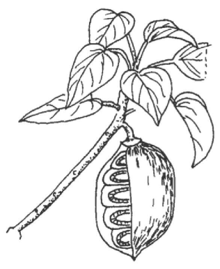

**Figure 11.7:** *Pangium edule*

The seed is buried for 2-3 weeks in beach sand or soaked in fresh or salt water to make it edible, then roasted and fermented (Peekel 1984: 384, Hviding 2005: 121, Bourke & Allen forthcoming). The Sengseng of New Britain trade it as a delicacy (A. Chowning, pers. comm.). The practice of eating the seeds extends eastward as far as Marovo (Evans 1999:21), but Hviding does not mention their consumption. The seeds are a famine food in Vanuatu (Walter & Sam 2002: 47).

A well known use of *Pangium edule* seed cases in the Bismarcks, the Solomons and Vanuatu is in the manufacture of bangles and rattles for traditional dances. In the Solomons the leaves are heated in the fire and used to kill headlice. The wood is generally not regarded as suitable for construction (Henderson & Hancock 1988:246, Hviding 2005: 121).

The only reconstructable term for *Pangium edule* is PEOc *paRage. Given that the tree is present in the Bismarcks, it seems odd that no POc or PWOc term can be reconstructed, but this may be due to the absence of relevant data from the sources.

| **PEOc** |  | *paRage | ‘*Pangium edule*’ |
| --- | --- | --- | --- |
| SES | Tolo | *valage* | ‘k.o. larger seed pod worn to make noise while dancing’ |
| SES | Kwara’ae | *falake* | ‘*Pangium edule*’ (Whitmore 1966) |
| SES | Lau | *falake* | ‘tree sp.; its seeds tied to legs in dancing’ |
| SES | Kwaio | *falage* | ‘rattle’ |
| SES | Arosi | *harage* | ‘sacred tree, has power to kill dogs’ |
| NCV | Mwotlap | *(wo)pyak* | ‘*Pangium edule*’ |
| NCV | Mota | *varake* | ‘tree sp .; its shells tied on the ankles as rattles in dancing’ |
| NCV | Araki | *lahe* | ‘*Pangium edule*’ |
| NCV | Tamambo | *varaŋe* | ‘*Pangium edule*’ |
| NCV | Nduindui | *vaŋe* | ‘*Pangium edule*’ |
| NCV | Ambae | *vake* | ‘*Pangium edule*’ |
| NCV | Raga | *vaŋe* | ‘*Pangium edule*’ |
| NCV | Sakao | *ne-vaɣ* | ‘*Pangium edule*’ |
| NCV | Sa | *wak* | ‘*Pangium edule*’ |
| NCV | Nāti | *ne-vaŋk* | ‘*Pangium edule*’ |
| NCV | Port Sandwich | *(vi)vaŋg* | ‘dance rattles’ |

## 3. Domesticated fruit trees

### 3.1. *Burckella obovata* (syn. *Bassia erskineana*, *Payena mentzelii*, *Illipe hollrungii*), red silkwood, TP *bukabuk*, B *naduldule*, *nandunde* (Sapotaceae)

*Burckella obovata* tends to grow on smaller islands. It occurs on the small islands west of Manus in the Admiralties, in New Ireland, in the island groups north and east of New Ireland, on the Duke of York Islands between New Britain and New Ireland, and on Buka and nearby small islands in Bougainville Province. It is also found in the Solomons on Malaita and in the Temotu Islands (and Hviding 2005: 111 reports its presence at Marovo) and in Vanuatu (Paijmans 1976: 124, Bourke n.d.). It is a tree of medium size, about 20–30 m. tall, with a massive trunk 1-3m in diameter at the base and white flowers that have a strong, somewhat sickening scent. It has large edible fruit that has a rose-petal-like smell and is consumed uncooked. In Vanuatu there are two main types of fruit: a more common elongated type, reputed to be sweeter, and a round, sometimes very large type. The latter has two subtypes, wrinkled and smooth. The smooth subtype is apparently the outcome of selection, and is always cultivated. In the Solomons and Vanuatu the fruit is harvested before it is ripe in order to beat the fruit bats (Walter & Sam 2002: 125). Two varieties grow in Marovo, wild and planted. Coconut crabs eat the fruit of the wild variety (Hviding 2005: 111).

In the Solomons and Vanuatu the wood is used for crossbeams in houses, for outrigger booms and for canoe paddles (Record 1945, Henderson & Hancock 1988:55, Walter & Sam 2002: 125). In Marovo it was formerly used for the keels of war canoes and is still sometimes used for making dugouts (Hviding 2005: 111).

The POc form *ñatu was first reconstructed by Blust (1978b) as an unnamed but described tree type. Further reflexes indicate that this is *Burckella obovata*, to which Gowers (1976: 38) gives the English designation ‘red silkwood’. Evidence for POc *-q is provided by Sye *yetu* and Ura *ni-yere* (John Lynch, pers. comm.), where preservation of the final vowel reflects the earlier presence of *-q.

The gloss of PMP *ñatuq below, ‘a hardwood tree taxon, including at least *Palaquium* spp.’, is inferred from the glosses of Blust’s supporting data. Species of *Burckella* and *Palaquium* and perhaps other genera seem to have been included in a single taxon throughout Oceanic history (see the discussion associated with PCP *bau ‘hardwood taxon’ in ch.7, §4.10).

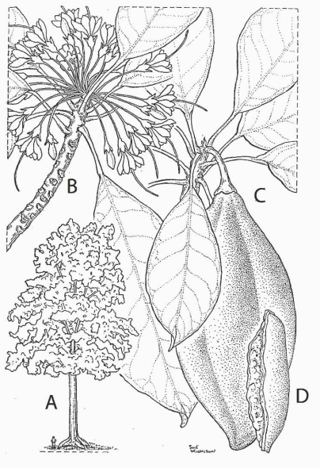

**Figure 11.8:** *Burckella obovata*: **A**, tree; **B**, flowering shoot; **C**, shoot bearing fruit; **D**, old seed.

| **PMP** |  | *ñatuq | ‘a hardwood tree taxon, including at least *Palaquium* spp.’ (Blust 1978b: 38-39) |
| --- | --- | --- | --- |
| **POc** |  | *ñatuq | ‘*Burckella obovata*’ (Blust 1978b: 38-39: *ñatu; Ross 1996d) |
| Adm | Mussau | *natu* | ‘*Burckella obovata*’ |
| Adm | Nauna | *ñot* | ‘tall timber tree with large sweet green fruit’ |
| Adm | Titan | *ñat* | ‘tall timber tree with large sweet green fruit’ |
| Adm | Nyindrou | *ñek* | ‘tall timber tree with large sweet green fruit’ |
| Adm | Bipi | *ñak* | ‘tall timber tree with large sweet green fruit’ |
| Adm | Loniu | *ñat* | ‘tall timber tree with large sweet green fruit’ |
| Adm | Baluan | *nout* | ‘*Burckella obovata*’ |
| NNG | Takia | *nat* | ‘tree (with edible nuts or fruit, also used for timber)’ |
| NNG | Gedaged | *nat* | ‘tree, Sapotaceae’ |
| PT | Kilivila | *natu* | ‘sp. of fruit tree’ |
| PT | Muyuw | *a-ntu-nat* | ‘*Palaquium* sp.’ |
| PT | Wedau | *natu* | ‘Malay apple, Eugenia megacarpa’ |
| MM | East Kara | *nətu* | ‘*Burckella obovata*’ |
| MM | Sursurunga | *nat* | ‘tree sp. with avocado-type fruit’ |
| MM | Ramoaaina | *natu* | ‘tree sp. with a large pulpy fruit like an apple’ |
| MM | Nehan | *not* | ‘*Palaquium* sp.; *Burckella obovata*’ |
| MM | Babatana | *natu* | ‘*Burckella obovata*’ |
| MM | Nduke | *natu* | ‘tree sp.’ |
| MM | Kubokota | *ñatu* | ‘*Burckella obovata*’ |
| TM | Äiwoo | *ñi-nou* | ‘*Burckella obovata*’ |
| TM | Natügu | *no-neu* | ‘*Burckella obovata*’ |
| **PEOc** |  | *ñatuq | ‘*Burckella obovata*’ |
| SES | Sa’a | *nau* | ‘a fruit tree, teak’ |
| SES | Arosi | *nau* | ‘tree sp., fruit is eaten’ |
| NCV | Mwotlap | *net* | ‘*Burckella obovata*’ |
| NCV | Mota | *natu* | ‘a fruit tree’ |
| NCV | Araki | *(vi)naru* | ‘*Burckella obovata*’ |
| NCV | Uripiv | *nor* | ‘*Burckella obovata*’ |
| NCV | Paamese | *a-natu* | ‘*Burckella obovata*’ |
| NCV | Lewo | *nar* | ‘*Burckella obovata*’ |
| NCV | Nguna | *na-natu* | ‘*Burckella obovata*’ |
| **PSV** |  | *nə-yatuq | ‘*Burckella obovata*’ (Lynch 2001c) |
| SV | Sye | *yetu* | ‘*Burckella obovata*’ |
| SV | Anejom̃ | *n-yat* | ‘*Burckella obovata*’ |
| SV | Ura | *ni-yere* | ‘*Burckella obovata*’ |
| Pn | Rennellese | *natu* | ‘*Burckella obovata*’ |
| Pn | Tikopia | *natu* | ‘*Burckella obovata*’ |
| Pn | Anutan | *natu* | ‘*Burckella obovata*’ |

### 3.2. *Clymenia polyandra* and *Citrus* spp. (Rutaceae)

Barrau (1955: 85) considers that all edible species of the genus *Citrus* were introduced to Melanesia by Europeans, and R. M. Bourke’s (pers. comm.) research confirms this. We would not therefore expect to find a reconstructable POc term meaning ‘citrus’. But the reconstruction of POc *molis ‘citrus fruit’ is well-supported (Lynch 1984), and its reflexes are today used in many languages for several citrus species.

How are we to explain this? There are two possible answers. One is that *molis referred not to *Citrus* species but to citrus-like fruit indigenous to western Melanesia. Aburu (1982) reports on two indigenous citrus-like genera, Clymenia and Microcitrus in Papua New Guinea. French (1986: 232) describes *Clymenia polyandra* as a ‘*Citrus* relative’ whose fruit is yellow, the size of a large lime, and in some cases ‘sweet and pleasant-tasting’. The tree is 5-8 m tall. It is cultivated in Manus and New Ireland (where it was also recorded by Peekel (1984: 272)) and does not occur outside Papua New Guinea.

The alternative answer is that there were inedible or barely edible *Citrus* species in Melanesia before European contact, which have been largely replaced by imported edible species. A bush lemon, *Citrus* hystrix, with almost no edible flesh (French 1986: 226) may be one of these. We can only infer that POc *molis designated either citrus-like genera or inedible species of *Citrus*, or both.[^24]:

| **POc** |  | *molis | ‘citrus fruit or citrus-like fruit, perhaps *Clymenia polyandra*’ (Lynch 1984) |
| --- | --- | --- | --- |
| Adm | Mussau | *muli* | ‘citrus fruit’ |
| Adm | Drehet | *mʷili* | ‘citrus fruit: pomelo’ |
| NNG | Atui | *molis* | ‘citrus fruit’ |
| NNG | Mangseng | *mɔlis* | ‘citrus fruit’ |
| MM | Vitu | *moli* | ‘citrus fruit’ |
| MM | Patpatar | *mulis* | ‘citrus fruit’ |
| MM | Nehan | *molih* | ‘*Clymenia polyandra*’ |
| MM | Halia | *molihi* | ‘citrus fruit’ |
| MM | Kia | *mholi* | ‘*Citrus* sp.’ |
| SES | Bugotu | *moli* | ‘*Citrus sinensis*’ (W. McClatchey, pers. comm.) |
| SES | Lau | *moli* | ‘introduced citrus fruit’ |
| SES | Arosi | *mori* | ‘wild orange’ |
| NCV | Mwotlap | *nı-mʷıl* | ‘*Citrus medica*’ |
| NCV | Mota | *mʷol* | ‘*Citrus medica*’ |
| NCV | Tamambo | *moli* | ‘orange’ |
| NCV | Tape | *mʷələs* | ‘citrus fruit’ |
| NCV | Uripiv | *na-mul* | ‘citrus fruit’ |
| NCV | Port Sandwich | *vi-mor* | ‘orange’ |
| NCV | Lonwolwol | *wo-mul* | ‘citrus fruit’ |
| NCV | Paamese | *a-moli* | ‘citrus fruit’ |
| NCV | Lewo | *mʷolu* | ‘citrus fruit’ |
| NCV | Namakir | *mol* | ‘citrus fruit’ |
| NCV | Nguna | *na-mwoli* | ‘citrus fruit’ |
| **PSV** |  | *ne-molis | ‘citrus fruit’ (Lynch 2001c) |
| SV | Sye | *ne-mli* | ‘citrus fruit’ |
| SV | Lenakel | *nə-məlh* | ‘citrus fruit’ |
| SV | Southwest Tanna | *(kʷa)n-məlh* | ‘citrus fruit’ |
| SV | Kwamera | *nə-mərhi* | ‘citrus fruit’ |
| SV | Anejom̃ | *ne-pceθ* | ‘citrus fruit’ (*p* unexplained) |
| Fij | Wayan | *moli* | ‘citrus fruit (generic)’ |

### 3.3. *Corynocarpus cribbianus* (syn. *Corynocarpus australasicus*, *Corynocarpus cribbiana*, *Helicia cribbiana*) (Cocynocarpaceae)

A small fruit tree which was apparently cultivated in the past, *Corynocarpus cribbianus* is reported from the Admiralties, from offshore islands around Madang (north coast of New Guinea), from Tangga Island (east of New Ireland) and in the Solomons from Guadalcanal and Malaita, but apparently not in New Britain or New Ireland.[^25]: It grows to a height of 7-10 m on Tangga Island, but sometimes to 20m elsewhere in Papua New Guinea. The mango-shaped fruit, 10–12cm long and 8-10cm in diameter, grow in clusters at the ends of branches. They are sweet but not juicy, and eaten raw or boiled. Two varieties are reported from Tangga and Kwara’ae: one has red, pear-shaped fruit, the other white and more ovoid. *Corynocarpus cribbianus* continues to be grown from seed in some places but has become rare in the Solomons, where it was apparently more widely cultivated in the past. Today it is only a snack food for hunters in the forest (French 1986:234, O’ Collins & Lamothe 1989, Kwa’ioloa & Burt 2001: 168).

Yen (1974a) reports a previously domesticated species of *Corynocarpus* on Santa Cruz Island (Te Motu group, Solomon Islands). This may well have been *Corynocarpus similis*, which grows wild under the forest canopy in parts of Vanuatu and is cultivated there. Indeed, Walter and Sam’s (2002: 152-153) description could easily be a description of *Corynocarpus cribbianus*, right down to its two varieties. Today it is regularly eaten only on the Torres Islands, where it was formerly cultivated and the fruits eaten boiled just before they became ripe, and on Tanna. Elsewhere it is a famine food. The wood is used for digging sticks or utensil handles.

POc *i(u)bu ‘*Corynocarpus cribbianus*’ is tentatively reconstructed - ‘tentatively’ because the forms shown under ‘cf. also’ appear to be formally connected with the members of this set, suggesting a PEOc *tabʷV, but the history of these forms or their relationship to the apparent reflexes of *i(u)bu is unclear.

| **POc** |  | *i(u)bu | ‘*Corynocarpus cribbianus*’ |
| --- | --- | --- | --- |
| Adm | Nyindrou | *ñ-iubu* | ‘*Corynocarpus* sp.’ (O’Collins and Lamothe 1989) |
| MM | Roviana | *ib-ibu* | ‘Cleidion spiciflorum’ (Henderson and Hancock 1988) |
| TM | Äiwoo | *(nua)dabu* | ‘*Corynocarpus cribbianus*’ (Henderson and Hancock 1988) |
| SES | Kwara’ae | *ibo* | ‘*Corynocarpus cribbianus*’ (Henderson and Hancock 1988) |
| SES | Kwaio | *ibo* | ‘*Corynocarpus cribbianus*’ (Henderson and Hancock 1988) |

cf. also:

| SES | Lengo | *tebu* | ‘*Corynocarpus cribbianus*’(Henderson and Hancock 1988) |
| --- | --- | --- | --- |
| SES | To’aba’ita | *tebu* | ‘*Corynocarpus cribbianus*’(Henderson and Hancock 1988) |
| NCV | Tamambo | *tabʷea* | ‘*Corynocarpus similis*’(Walter and Sam 2002) |
| NCV | Apma | *tabʷi* | ‘*Corynocarpus similis*’(Walter and Sam 2002) |

### 3.4. *Mangifera* spp., mango (Anacardiaceae)

We cannot be completely sure of the original referents of the five mango terms reconstructed below. When Austronesian speakers arrived in the Bismarcks, they encountered the fibrous and ill-tasting indigenous mangoes *Mangifera minor* and *Mangifera foetida*. The sweet-tasting *Mangifera indica*, the species widely consumed today, arrived with Europeans after about 1870 (Bourke forthcoming).

It is possible that PMP *pahuq referred to *Mangifera indica* and PMP *wai to other *Mangifera* species (ACD). I have found only two reflexes of PMP *pahuq in Oceanic languags, namely Vitu *vau* and Bola *vao*. Vitu (in the French Islands, north of New Britain) is among the most conservative of Oceanic languages, and has remained quite isolated at least since early in the spread of the Western Oceanic dialect network. Bola is close by on New Britain. One may infer that *pau(q) occurred in POc, but not with the gloss ‘*Mangifera indica*’. It was replaced at a very early stage by *wai, as this was the appropriate term for the indigenous (non-indica) species, with *wai-wai perhaps denoting wild varieties (§7.2). The species *Mangifera minor* was specifically designated by POc *koRa.

*Mangifera minor*, the traditional wild mango indigenous to the Bismarcks, is 10-25 m tall. The introduced *Mangifera indica* needs a drier period each year to bear, whereas *Mangifera minor* does not, and so the latter continues to be eaten mainly in locations where *Mangifera indica* does not bear regularly. It is occasionally cultivated from seed. Its leaves are narrower than those of M . indica (Peekel 1984: 326, French 1986:206–207, Bourke in preparation, n.d.).

| **PMP** |  | *pahuq | ‘mango, probably *Mangifera indica*’ (Dyen 1953) |
| --- | --- | --- | --- |
| **POc** |  | *pau(q) | ‘mango, *Mangifera* sp. (not indica)’ (Ross 1996d) |
| MM | Vitu | *vau* | ‘mango’ |
| MM | Bola | *vao* | ‘mango’ (Arentz et al. 1989: 91) |

| **PMP** |  | *wai | ‘mango spp.’ (Blust 1986) |
| --- | --- | --- | --- |
| **POc** |  | *wai, *waiwai | ‘mango (generic)’ (Ross 1996d) |
| Adm | Titan | *we-wey* | ‘mango’ |
| Adm | Baluan | *wie* | ‘mango’ |
| NNG | Gitua | *wo-wai* | ‘mango’ |
| NNG | Mangap | *we* | ‘mango’ |
| NNG | Tami | *woa-wai* | ‘mango’ |
| NNG | Gitua | *wo-wai* | ‘mango’ |
| NNG | Mangap | *we* | ‘mango’ |
| PT | Kilivila | *wei-wa* | ‘mango’ |
| PT | Hula | *wai-wai* | ‘mango’ |
| SES | Arosi | *wai-wai* | ‘sp. of small tree’ |

| **POc** |  | *koRa | ‘wild mango, *Mangifera minor*’ (Ross 1996d) |
| --- | --- | --- | --- |
| NNG | Mengen | *kula* | ‘mango; has strings in it, *Mangifera minor*(?)’ |
| PT | Roro | *or-or* | ‘mango’ |
| MM | Tolai | *ko-kor* | ‘*Mangifera minor*(?)’ |
| SES | Gela | *kola* | ‘mango’ |

PWOc *kasuwai ‘mango’ seems to be a compound, with an unidentified element *kasu- and *wai ‘mango’. The SE Solomons terms below reflect PSES *ɣohai, which in turn reflects a putative POc †*koyai. However, PSES *ɣohai probably reflects the borrowing of a reflex of *kasuwai, perhaps before the dispersal of PSES, as the terms are regular reflexes of *ɣohai.

| **PWOc** |  | *kasuwai | ‘mango’ (Ross 1996d) |
| --- | --- | --- | --- |
| NNG | Kove | *korae* | ‘mango’ (A. Chowning, pers. comm.) |
| PT | Dobu | *kasawe* | ‘mango’ |
| PT | Tawala | *kasawe* | ‘mango’ |
| MM | Patpatar | *kasaua* | ‘mango, *Mangifera indica*’ |
| MM | Bulu | *korae* | ‘mango’ |
| MM | Tolai | *koai* | ‘mango’ |
| MM | Siar | *kaswai* | ‘mango’ |
| MM | Banoni | *dasowe* | ‘mango’ (for †_zasowe) |
| MM | Blablanga | *kesu* | ‘mango’ |

cf. also:

| SES | West Guadalcanal | *ɣoai* | ‘mango’ |
| --- | --- | --- | --- |
| SES | Longgu | *ʔeðai* | ‘mango’ |
| SES | Arosi | *ʔāi* | ‘mango’ |
| SES | Fagani | *ɣāi* | ‘mango’ |

| **PWOc** |  | *basi | ‘mango’ (Ross 1996d) |
| --- | --- | --- | --- |
| PT | Tawala | *basi(awa)* | ‘mango’ |
| PT | Sudest | *mbaði* | ‘mango’ |
| MM | Teop | *bai* | ‘mango’ |
| MM | Tinputz | *pᴂʔ* | ‘mango’ |

### 3.5. *Pometia pinnata*, ocean lychee, island lychee, TP *ton*, *taun*, P *obit*, *inkori*, B *nandao* (Sapindaceae)

*Pometia pinnata*, an ancient New Guinea domesticate (Yen 1996), is a tall canopy hardwood tree of 20–45 m (Figure 11.9, left). Peekel (1984: 335) writes that its fruit, green or red and 4–6cm in diameter, the sweet pulp of which similar in taste and texture to a lychee and is eaten raw, is the most valued in the Bismarck Archipelago after the Malay apple. The skin of the ripe fruit is peeled off like that of a mandarin. The pulp surrounds a seed, up to 3 cm in diameter, which is poisonous and requires extensive processing and cooking before it can be eaten. French (1986: 215) reports that there are also varieties of *Pometia pinnata* with inedible flesh.

*Pometia pinnata* displays considerable variety in form, especially in the New Guinea region, attesting to long cultivation. Walter & Sam (20102: 229-230) report that its better forms are often transplanted in the Bismarcks and in Vanuatu but apparently less so in the Solomons. There are also widespread reports that it makes good building timber (Floyd 1954, Gowers 1976: 118, French 1986: 215). The wood is also used for carving on Waya (Gardner & Pawley 2006), and its plank buttresses provide axe handles in Marovo (Hviding 2005: 129).

The POc term for *Pometia pinnata* was *tawan, reflected in all major Oceanic subgroups except Micronesian.

| **PEMP** |  | *tawan | ‘*Pometia pinnata*’ (Blust 1978a) |
| --- | --- | --- | --- |
| **POc** |  | *tawan | ‘*Pometia pinnata*’ |
| Adm | Mussau | *taon* | ‘*Pometia pinnata*’ |
| Adm | Lou | *ta* | ‘*Pometia pinnata*’ |
| NNG | Mengen | *taua* | ‘*Pometia pinnata*’ |
| NNG | Gedaged | *tau* | ‘tree sp. with edible fruit; stem makes good timber.’ |
| NNG | Matukar | *ta* | ‘*Pometia pinnata*’ (Kasprus 1945) |
| NNG | Megiar | *tau(ber)* | ‘*Pometia pinnata*’ (Kasprus 1945) |
| PT | Bwaidoga | *tawana* | ‘tree sp.’ |
| MM | Lavongai | *ton* | ‘*Pometia pinnata*’ |
| MM | East Kara | *tawən* | ‘*Pometia pinnata*’ |
| MM | Lihir | *ta* | ‘*Pometia pinnata*’ |
| MM | Sursurunga | *tawan* | ‘*Pometia pinnata*’ |
| MM | Patpatar | *tawan* | ‘*Pometia pinnata*’ |
| MM | Tolai | *ton* | ‘*Pometia pinnata*’ |
| MM | Tangga | *taun* | ‘*Pometia pinnata*’ |
| MM | Sursurunga | *taoana* | ‘a hardwood tree’ |
| MM | Petats | *tan* | ‘*Pometia pinnata*’ |
| MM | Teop | *tauana* | ‘*Pometia pinnata*’ |
| TM | Natügu | *no-dae* | ‘*Pometia pinnata*’ |
| **PEOc** |  | *tawan | ‘*Pometia pinnata*’ |
| SES | Lengo | *tao* | ‘*Pometia pinnata*’ (Henderson and Hancock 1988) |
| SES | Arosi | *awa* | ‘*Pometia pinnata*’ |
| SES | Sa’a | *awa* | ‘Nephelium pinnatum’ |
| SES | Kwara’ae | *ako* | ‘*Pometia pinnata*’ |
| SES | Kwara’ae | *dawa* | ‘*Pometia pinnata*’ (borrowed form) |
| NCV | Mwotlap | *na-twen* | ‘*Pometia pinnata*’ |
| NCV | Mota | *tawan* | ‘*Pometia pinnata*’ |
| NCV | Ambae | *dao* | ‘*Pometia pinnata*’ |
| NCV | Araki | *(vi)ca* | ‘*Pometia pinnata*’ |
| NCV | Raga | *dao* | ‘*Pometia pinnata*’ (Walsh 2004) |
| NCV | Big Nambas | *da-dau* | ‘*Pometia pinnata*’ |
| NCV | Port Sandwich | *na-ⁿrao* | ‘*Pometia pinnata*’ |
| NCV | Namakir | *to* | ‘*Pometia pinnata*’ |
| NCV | Nguna | *na-dau* | ‘*Pometia pinnata*’ |
| **PSV** |  | *na-ntawa(n) | ‘*Pometia pinnata*’ (Lynch 2001c) |
| SV | Sye | *ntau* | ‘*Pometia pinnata*’ |
| SV | Lenakel | *natəm* | ‘*Pometia pinnata*’ (*-m* unexplained) |
| SV | Kwamera | *nətumʷi* | ‘*Pometia pinnata*’ (*-mʷi* unexplained) |
| SV | Anejom̃ | *netva* | ‘*Pometia pinnata*’ |
| **PCP** |  | *tawa | ‘*Pometia pinnata*’ |
| Fij | Wayan | *tawa* | ‘*Pometia pinnata*’ |
| Fij | Bauan | *dawa* | ‘*Pometia pinnata*’ |
| Pn | Tongan | *tava* | ‘*Pometia pinnata*’ |
| Pn | Niuean | *tava* | ‘*Pometia pinnata*’ |
| Pn | Samoan | *tava* | ‘*Pometia pinnata*’ |
| Pn | East Futunan | *tava* | ‘*Pometia pinnata*’ |
| Pn | Emae | *tava* | ‘*Pometia pinnata*’ |
| Pn | Tikopia | *tava* | ‘*Pometia pinnata*’ |
| Pn | Tuamotuan | *tava* | ‘*Pandanus* sp.’ |
| Pn | Māori | *tawa* | ‘*Beilschmiedia tawa*’ |

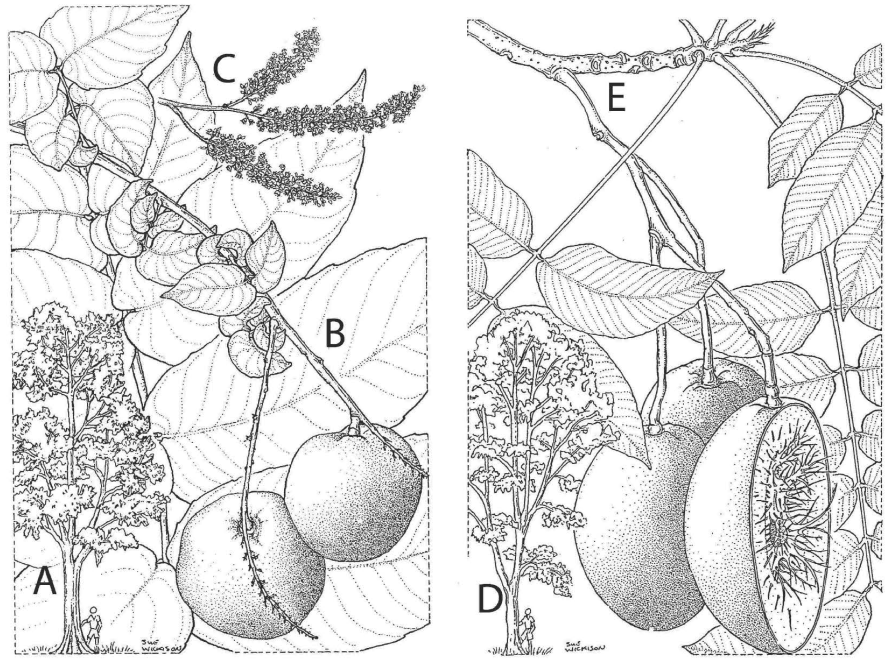

**Figure 11.9:** **Left** *Pometia pinnata*, island lychee: **A**, young tree; **B**, shoot and edible fruit; **C**, inflorescence. **Right** *Spondias cytherea*, golden apple: **D**, young tree; **E**, shoot with leaves, leaflets and a cluster of edible fruit.

### 3.6. *Spondias cytherea* (syn. *Spondias dulcis*, *Spondias mangifera*), golden apple, Polynesian plum, hog plum, Tahitian apple, Bnaos (Anacardiaceae)

The mature tree has a long trunk of up to 20 m with large buttresses up to 3 m. Its small white flowers grow in clusters, and it has yellow or orange ellipsoid fruit, up to 7cm long. According to Henderson & Hancock (1988: 47) there are two varieties. The fruit of one are acidic and bitter, of the other slightly tart but pleasant to eat. The former are baked before eating, whilst the latter are eaten raw. Hviding (2005: 135) reports of the second variety that in Marovo the fruit are best eaten when unripe and rather sour. In Vanuatu the fruit are of better quality than in the Bismarcks and the Solomons. They are picked while still green, just before they ripen, and eaten a few days later after they have ripened inside the house.

The wood is too soft for use in buildings, but in Vanuatu it is used to make canoe outriggers. It has a variety of medicinal uses: a decoction from the leaves is used for coughs and other ailments (Henderson & Hancock 1988: 49).

There was a single widely reflected POc term, *quRis. I have assumed below that the PCP form was *wi, with irregular loss of *q- from expected †*qul. However, loss of *q- is regular in Fijian, and so Fijian *wī* is a regular reflex of either proto form. Geraghty (2004: 87) suggests that the PCP form was indeed *qui and that the Polynesian forms reflect borrowing from Fijian - but such a borrowing would have had to occur very early, to find its way to the extremes of Polynesia. It seems more likely that the PCP indeed had *wī.

| **POc** |  | *quRis | ‘*Spondias cytherea*’ (Grace 1969 (Wilhelm Milke, pers. comm.: *quRi); Ross 1996d) |
| --- | --- | --- | --- |
| Adm | Loniu | *wi* | ‘*Spondias cytherea*’ |
| NNG | Mengen | *kuli* | ‘*Spondias cytherea*’ |
| PT | Motu | *uri* | ‘Garuga sp.’ (Lane-Poole 1925) [^26] |
| MM | Nakanai | *huri* | ‘*Spondias cytherea*’ |
| MM | East Kara | *us* | ‘*Spondias cytherea*’ |
| MM | Patpatar | *kulis* | ‘*Spondias cytherea*’ |
| MM | Tolai | *kuri* | ‘*Spondias cytherea*’ |
| TM | Natügu | *n-oli* | ‘*Spondias cytherea*’ |
| SES | Lau | *uli* | ‘*Spondias cytherea*’ |
| SES | Kwaio | *uli* | ‘*Spondias cytherea*’ |
| NCV | Mwotlap | *ıy* | ‘*Spondias cytherea*’ |
| NCV | Mota | *ur* | ‘*Spondias cytherea*’ |
| NCV | Vera’a | *n-ur* | ‘*Spondias cytherea*’ |
| **PSV** |  | *na-viris | ‘*Spondias cytherea*’ (Lynch 21004a) |
| SV | Sye | *ne-viwi* | ‘*Spondias cytherea*’ |
| SV | Ura | *(u)vasele* | ‘*Spondias cytherea*’ (metathesis) |
| SV | Kwamera | *nə-kori* | ‘*Dracontomelon vitiensis*’ |
| SV | Anejom̃ | *n-huri* | ‘*Dracontomelon vitiensis*’ |
| **PCP** |  | *wī | ‘*Spondias cytherea*’ |
| Fij | Bauan | *wī* | ‘*Spondias cytherea*’ |
| Pn | Tongan | *vī* | ‘*Spondias cytherea*’ |
| Pn | Niuean | *vī* | ‘*Spondias cytherea*’ |
| Pn | East Futunan | *vī* | ‘*Spondias cytherea*’ |
| Pn | Emae | *vī* | ‘*Spondias cytherea*’ |
| Pn | Rennellese | *bī* | ‘*Spondias cytherea*’ |
| Pn | Tikopia | *vī* | ‘*Spondias cytherea*’ |
| Pn | Samoan | *vī* | ‘*Spondias cytherea*’ |
| Pn | Tokelauan | *vī* | ‘mango species found only in Samoa’ |
| Pn | Rapanui | *bi* | ‘Indian mango tree, *Mangifera indica*’ |
| Pn | Marquesan | *vī* | ‘*Spondias cytherea*’ |
| Pn | Mangarevan | *vī* | ‘*Spondias cytherea*’ |
| Pn | Hawaiian | *vī* | ‘*Spondias cytherea*’ |
| Pn | Tahitian | *vī* | ‘*Spondias cytherea*’ |
| Pn | Rarotongan | *vī* | ‘*Spondias cytherea*’ |

In the Bismarcks an imported thorny shrub, *Ximenia americana* (syn. *X. elliptica*, *X. aculeata*),[^27]: is evidently perceived as resembling *Spondias cytherea*, to judge from the names below. The resemblance is based on the fact that *Ximenia americana* also has edible yellow ellipsoid fruit, but no larger than a cherry (Peekel 1984: 160). E Kara combines the POc prefix *mala- ‘resembling’ (ch.2, §7.1.4) and *ukis* ‘*Spondias cytherea*’. The base *ukis* is the reflex of POc *quRis ‘*Spondias cytherea*’ that would be expected in Tigak, immediately to the north of Kara. Further south, in Patpatar, the term for *Ximenia americana* is *ku-kuris*, the reduplication implying that *Ximenia americana* is an inferior or wild version of *Spondias cytherea* (ch.2, §7 .2).

| MM | East Kara | *mala-ukis* | ‘*Ximenia americana*’ (‘false *Spondias cytherea*’) |
| --- | --- | --- | --- |
| MM | Patpatar | *ku-kuris* | ‘*Ximenia americana*’ (‘small *Spondias cytherea*’) |
| MM | Tolai | *kuri-val* | ‘*Ximenia americana*’ (*kuri* ‘*Spondias cytherea*’)(Record 1945) |

PNCV *usi below appears to be an irregular reflex of POc *quRis. Two possible explanations present themselves. First, *(q)usi is a metathesised reflex of *quRis (> †*uis > *usi). Second, although POc final consonants were regularly lost in PNCV, Clark (2009) points to a dozen or so words in which the expected CVCV form exists alongside an extended form CVCVCV, representing the full POc form with an added vowel, most often *-i. The extended forms, for which Clark offers no explanation, are found throughout North Vanuatu and north Malakula, but without much consistency in any one language. One of these, in the form he reconstructs, is *quRisi, which with regular deletion of POc *q- and *-R- gives *u(i)si.

Some of these reflexes are (also) used to denote the pawpaw/papaya, *Carica papaya*, a recent introduction; this reflects a perception in Vanuatu that *Spondias cytherea* and papaya are similar and somehow related.

| **PNCV** |  | *usi | ‘*Spondias cytherea*’ (from data in Wheatley 1992) |
| --- | --- | --- | --- |
| NCV | Nduindui | *uhi* | ‘*Spondias cytherea*’ |
| NCV | Nduindui | *uhi(gai)* | (*gai* ‘tree’) |
| NCV | Ambae | *uhi* | ‘*Carica papaya*’ |
| NCV | Tangoa | *(vi)usi* | ‘*Spondias cytherea*’ |
| NCV | Nokuku | *o-usi* | ‘*Spondias cytherea*’ |
| NCV | Tolomako | *na-us* | ‘*Spondias cytherea*’ |
| NCV | Kiai | *usi* | ‘*Spondias cytherea*’ |
| NCV | Raga | *uhi* | ‘*Spondias cytherea*, *Carica papaya*’ |
| NCV | Uripiv | *na-us* | ‘*Spondias cytherea*, *Carica papaya*’ |
| NCV | Nese | *na-us* | ‘*Spondias cytherea*’ |
| NCV | Southwest Bay | *ni-vus(-saruei)* | ‘*Spondias cytherea*’ |

There are two possible external cognates of the PNCV etymon below. The first is Mussau (Adm) *malai* ‘*Spondias cytherea*’ (Lepofsky 1992). However, Mussau *-ai* does not correspond regularly with Paamese, Nguna *-i*. The second is Wayan (Fij) *māoli* ‘*Spondias cytherea*’, but Wayan *-āo-* does not correspond regularly with PNCV *-a-. In parts of northern Vanuatu the term has been reapplied to *Dracontomelon vitiense* (ch.7, §4.4).

| **PNCV** |  | *mali | ‘*Spondias cytherea*’ (Clark 1996) |
| --- | --- | --- | --- |
| NCV | Nokuku | *mal* | ‘*Dracontomelon vitiense*’ |
| NCV | Araki | *(vi)nᫀali* | ‘*Dracontomelon*’ |
| NCV | Port Sandwich | *mar(kokoc)* | ‘*Spondias cytherea*’ |
| NCV | Lonwolwol | *mel* | ‘a large tree with yellow edible fruit’ |
| NCV | Southeast Ambrym | *mal* | ‘*Dracontomelon vitiense*’ |
| NCV | Paamese | *mali-mali* | ‘*Spondias cytherea*’ |
| NCV | Lewo | *(puru)mel-mel* | ‘*Spondias cytherea*’ |
| NCV | Baki | *(bur)mel-mel* | ‘*Spondias cytherea*’ |
| NCV | Namakir | *mali-mal* | ‘*Spondias cytherea*’ |
| NCV | Nguna | *na-mali* | ‘*Spondias cytherea*’ |
| NCV | South Efate | *n-mal* | ‘*Spondias cytherea*, S. edulis’ |

Also puzzling is the connection between PNCV *mali and the items for *Garuga floribunda* listed below. There is reason to think that this is not a chance resemblance, as the PROc term *mala-usi ‘Garuga sp.’ literally meant ‘like *Spondias cytherea*’ (ch.7, §4.8), i.e. there was/is a perceived resemblance between Garuga and Spondias species. We cannot simply include the items below in the cognate set for PNCV *mali above, however, as the Paamese, Lewo and S Efate reflexes of *mal-mali differ from their reflexes of *mali.

| **PNCV** |  | *mal-mali | ‘*Garuga floribunda*’ |
| --- | --- | --- | --- |
| NCV | Mwotlap | *na-mal-mali (ey)* | ‘*Garuga floribunda*’ |
| NCV | Paamese | *e-imoumol* | ‘*Garuga floribunda*’ |
| NCV | Lewo | *(puru)mal-mal* | ‘*Garuga floribunda*’ |
| NCV | Baki | *(buru)mar-maro* | ‘*Garuga floribunda*’ |
| NCV | South Efate | *n(a)-mal-mil* | ‘*Garuga floribunda*’ |

### 3.7. *Syzygium malaccense* (syn. *Eugenia malaccensis*, *Eugenia jambos*, jambosa malaccensis), Malay apple, rose apple, TP *laulau*, P *kabarae*, B *nakavika* (Myrtaceae)

Many *Syzygium* species which occur in the Pacific have edible fruit. The most important is *Syzygium malaccense*, which is distributed from SE Asia to Polynesia, but Peekel (1984: 408-415) and Walter & Sam (2002: 251-252) list numerous species which occur in NW Island Melanesia.

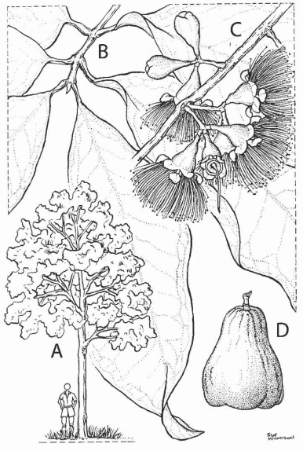

**Figure 11.10:** *Syzygium malaccense*: **A**, tree; **B**, shoot; **C**, branch with opened and unopened flowers; **D**, edible fruit.

*Syzygium malaccense* is an erect tree of medium height, 5-25 m tall, with spectacular white or pink flowers that look like small powder puffs and ellipsoid two-seeded fruit 4–9cm long that are white, pink or red when they are mature. The fruit approach a European apple in texture, but are often more watery in flavour. They are widely and, to quote Sorensen, ‘avidly’ consumed throughout the Pacific (Sorensen 1950, Peekel 1984: 408, Walter & Sam 2002: 250, Bourke in preparation). They are eaten fresh, soon after picking. *Syzygium malaccense* is found around villages and in coconut groves, in gardens and old fallows, and in open forests, although it is not clear whether it is indigenous to Melanesia or whether cultivated varieties have simply propagated themselves into the wild. Transplantation of better forms to village and garden areas is widespread (Paijmans 1976: 123-124, Walter & Sam 2002: 250). The wood is used for buildings in Vanuatu and Fiji, and for canoes in Vanuatu. Juice extracted from the leaves is used for abdominal pains, sore throats, toothache and generally for pain and fever (Henderson & Hancock 1988: 43-44, Walter & Sam 2002: 250).

The POc term for *Syzygium malaccense* was *kapika, reflected in all major Oceanic subgroups except Micronesian. It may also have served as a generic for *Syzygium* species in general.

| **POc** |  | *kapika | ‘Malay apple, rose apple, *Syzygium malaccense*’ (Milke 1968) |
| --- | --- | --- | --- |
| Adm | Mussau | *kaviu* | ‘*Syzygium samarangense*’ (*-u* for †*-a*) |
| Adm | Seimat | *ahi* | ‘*Syzygium* sp.’ (Sorensen 1950) |
| Adm | Lou | *keik* | ‘large variety of Malay apple, *Syzygium* gomata’[^28] |
| **PWOc** |  | *kapika | ‘*Syzygium malaccense*’ |
| NNG | Mengen | *gaiva* | ‘rose apple, *Syzygium malaccense*’ |
| NNG | Tami | *kapig* | ‘rose apple, *Syzygium malaccense*’ |
| NNG | Yabem | *àiŋ* | ‘rose apple’ |
| PT | Motu | *ɣavika* | ‘name of tree sp., leaves of which are used as cigarette wrappers’ |
| MM | Nakanai | *gaiva* | ‘*Syzygium malaccense*’ (Floyd 1954) |
| MM | Bola | *kavika* | ‘*Syzygium malaccense*’ |
| MM | Bulu | *kavika* | ‘*Syzygium malaccense*’ |
| MM | Babatana | *kapika* | ‘*Syzygium malaccense*’ |
| **PEOc** |  | *kapika | ‘*Syzygium malaccense*’ |
| SES | Gela | *ɣaviɣa* | ‘*Syzygium malaccense*’ |
| SES | Kwara’ae | *ʔafiʔo* | ‘*Syzygium malaccense*’ |
| SES | Lau | *afio* | ‘*Syzygium* onesimum’ |
| NCV | Mota | *gaviga* | ‘*Syzygium malaccense*, wild inedible variety’ |
| NCV | Araki | *haviha* | ‘*Syzygium malaccense*’ |
| NCV | Tamambo | *haviha* | ‘Malay apple’ |
| NCV | Raga | *ɣaviɣa* | ‘Malay apple (Walsh 2004)’ |
| NCV | Uripiv | *n-avi* | ‘Malay apple’ |
| NCV | Port Sandwich | *xavik* | ‘Malay apple’ |
| NCV | Paamese | *ahie* | ‘Malay apple’ |
| NCV | Lewo | *kavika* | ‘Malay apple’ |
| NCV | Namakir | *kavik* | ‘Malay apple’ |
| NCV | Nguna | *na-kavika* | ‘Malay apple’ |
| NCV | South Efate | *n-kafik* | ‘Malay apple’ |
| **PSV** |  | *na-ɣaviɣ | ‘*Syzygium malaccense*’ (Lynch 2001c) |
| SV | Lenakel | *nə-kəvək* | ‘*Syzygium malaccense*’ |
| SV | Anejom̃ | *n-yeheɣ* | ‘*Syzygium malaccense*’ |
| NCal | Pije | *cāk* | ‘*Syzygium malaccense*’ |
| NCal | Iaai | *xəiə* | ‘*Syzygium malaccense*’ |
| NCal | Nyelâyu | *cāc* | ‘*Syzygium malaccense*’ |
| NCal | Xârâcùù | *kʌɨ* | ‘*Syzygium malaccense*’ |
| **PCP** |  | *kavika | ‘*Syzygium malaccense*’ |
| Fij | Wayan | *kavika* | ‘*Syzygium malaccense*’ |
| Fij | Bauan | *kavika* | ‘*Syzygium malaccense*’ |
| Pn | Tongan | *fekika* | ‘*Syzygium malaccense*’ (metathesis) |
| Pn | Niuean | *kafika* | ‘*Syzygium* sp.’ |
| Pn | Anutan | *kapika* | ‘*Syzygium malaccense*’ |
| Pn | East Futunan | *kafika* | ‘*Syzygium malaccense*’ |
| Pn | East Uvean | *kafika* | ‘*Syzygium malaccense*’ |
| Pn | Tikopia | *kafika* | ‘*Syzygium malaccense*’ |
| Pn | Marquesan | *kehika* | ‘*Syzygium malaccense*’ |
| Pn | Mangarevan | *keʔika* | ‘*Syzygium malaccense*’ |
| Pn | Tahitian | *ʔahiʔa* | ‘*Syzygium malaccense*’ |
| Pn | Hawaiian | *ʔoohia(ʔai)* | ‘*Syzygium malaccense*’ |
| Pn | Hawaiian | *ʔoohia(lehua)* | ‘Metrosideros spp.’ |
| Pn | Rarotongan | *kaʔika* | ‘*Syzygium malaccense*’ |
| Pn | Māori | *kahika* | ‘*Metrosideros fulgens*, *Dacrycarpus dacrydioides*’ (R. Gardner, pers. comm.) |

The three more narrowly distributed cognate sets below reflect other terms for *Syzygium* species. Whether these denoted cultivars of *Syzygium malaccense* or other species, it is impossible to say.

| **POc** |  | *poka(q) | ‘variety of Malay apple’ |
| --- | --- | --- | --- |
| Adm | Mussau | *oā* | ‘small variety of Malay apple, *Syzygium* gomata’ |
| NNG | Bariai | *poai* | ‘*Syzygium* sp.’ (Goulden 1996) |
| NNG | Kilenge | *pokai* | ‘*Syzygium* sp.’ (Goulden 1996) |

| **POc** |  | *mari(a)sapa | ‘*Syzygium* sp.’ |
| --- | --- | --- | --- |
| Adm | Nyindrou | *marisah* | ‘*Syzygium* sp.’ |
| MM | Patpatar | *mariasa* | ‘*Syzygium acutangulum*’ (for †_mariasaha) |

cf. also:

| MM | Nehan | *mariah* | ‘Alpinia sp.’ |
| --- | --- | --- | --- |

| **PAdm** |  | *cay | ‘*Syzygium* sp. with large red fruit’ |
| --- | --- | --- | --- |
| Adm | Baluan | *sai* | ‘*Syzygium malaccense*’ |
| Adm | Wuvulu | *tae* | ‘*Syzygium* sp. with large red fruit’ |
| Adm | Loniu | *cay* | ‘*Syzygium* sp. with large red fruit’ |
| Adm | Titan | *cay* | ‘*Syzygium* sp. with large red fruit’ |

## 4. Other nut and fruit trees

This section is devoted to nut- or fruit-bearing species that are popularly eaten in at least parts of NW Island Melanesia but for which there is no evidence of arboriculture.

In several cases, the literature on plant food production describes species for which we have been unable to reconstruct a term. These are:

- *Flacourtia rukam* is a small tree with a twisted trunk and red spherical fruits of 2cm diameter, distributed from island SE Asia to the Solomons but found cultivated further east. The fruit is occasionally eaten (Walter & Sam 2002: 173-174, Bourke n.d.).
- *Pouteria maclayana* is a common, self-sown, small, buttressed coastal tree with a bushy crown that grows in New Guinea, on offshore islands along its north coast and in the southeastern Solomon Islands. Its yellow-fleshed fruit, shaped like a flattened sphere, is occasionally eaten raw, in some places as a famine food (Henderson & Hancock 1988: 142-143, Walter & Sam 2002:233, Bourke n.d. ). Allen et al. (1994) list it among previously important foods on Karkar Island.
- *Castanopsis acuminatissima* is a tall oak-like tree whose seeds are a traditional forest food, eaten after boiling in New Guinea, New Britain and perhaps parts of the Solomons (Henty 1982, Evans 1999: 19).
- *Omphalea gageana* (syn. 0. papuana, 0. queenslandiae) is an uncommon large woody, high-climbing forest creeper, 20–30 m. long. Its fruit has three seeds enclosed in a thin fleshy mesocarp and a ridged undulating woody shell, which are eaten raw or cooked around the Huon Gulf and in SE Papua (Henty 1982, Peekell984: 317, Henderson & Hancock 1988: 76, Evans 1999: 19).
- *Gnetum latifolium* is another large woody, high-climbing forest creeper, 5-20 m long, with yellow-red fruits, the seeds of which are eaten after roasting (Peekel 1984: 37, Henderson & Hancock 1988:78, Evans 1999: 20).

The distributions of some of the above are such that they may have been unknown to speakers of POc, but it is also possible that our sources are not detailed enough to provide us with the data needed to support a reconstruction.

The fruits of several species of *Ficus* are eaten. Bourke (n.d.) names *Ficus copiosa*, *Ficus tinctoria* and *Ficus wassa*. These are treated in ch.lO, §4.

### 4.1. *Finschia chloroxantha* (syn. *Finschia waterhousiana*, *Finschia densiflora*, *Grevillea densiflora*) (Proteaceae)

*Finschia chloroxantha* is a medium-sized lowland rain forest tree with a blackish trunk and stilt roots (Figure 11.11, right). When it blooms it makes a spectacular display of bright orange or light golden yellow pendulous flowers. Its seeds are edible, eaten raw as snacks in the Solomons and after cooking in New Guinea. Its red-brown wood is strong and is used for timber, furniture and drums in the Solomons. Its leaves were used to treat sores and ulcers on Santa Isabel (Henty 1982, Henderson & Hancock 1988:74–76, Evans 1999: 19, Kwa’ioloa & Burt 2001: 124).

The cognate set below allows only a PEOc reconstruction. The one Western Oceanic item, Maringe *ɣlama*, is probably a borrowing from a neighbouring SE Solomonic language, especially as Maringe *ɣl-* typically reflects POc *l-, not *g-. The species is not mentioned by Peekel (1984), a major source of botanical terms from New Ireland.

| MM | Maringe | *ɣlama* | ‘*Finschia chloroxantha*’(Henderson and Hancock 1988: 74) |
| --- | --- | --- | --- |

| **PEOc** |  | *gama | ‘*Finschia chloroxantha*’ |
| --- | --- | --- | --- |
| SES | Kwara’ae | *(a)kama* | ‘*Finschia chloroxantha*’ |
| SES | Lau | *(a)kame* | ‘*Finschia densiflora*’ |
| NCV | Tamambo | *(vu)kame* | ‘*Finschia chloroxantha*’ (Walter and Sam 2002: 293) |
| NCV | Apma | *(wa)gam* | ‘*Finschia chloroxantha*’ |
| **PSV** |  | *na-(i)gam | ‘*Finschia chloroxantha*’ (Lynch 2001c) |
| SV | Sye | *ne-iŋkom* | ‘*Finschia chloroxantha*’ |
| SV | Anejom̃ | *n-ikam* | ‘*Finschia chloroxantha*’ |

### 4.2. *Parartocarpus venenosa* (syn. *Parartocarpus involucrata*) (Moraceae)

*Parartocarpus venenosa* is a large lowland forest tree growing to about 35m, with girths of over 1.5 m, which resembles the breadfruit (Figure 11.11, left) (ch.9, §4). Its fruit is brown or yellow and highly aromatic; it forms an irregularly shaped syncarp about 18cm across, a compound fruit with many segments about 3cm long arranged around the core, and is eaten raw. It is especially popular in New Britain, but there is no record of cultivation. Elsewhere in lowland New Guinea, the Bismarcks and the Solomons it is generally less significant but is known and consumed (Barrau 1962: 177, Paijmans 1976: 124, Peekel 1984: 132, Bourke in preparation, French 1986: 259). Henderson & Hancock (1988) report that it is not very sweet and has a powdery texture: it is filling but not succulent. Its timber is generally not regarded as useful.

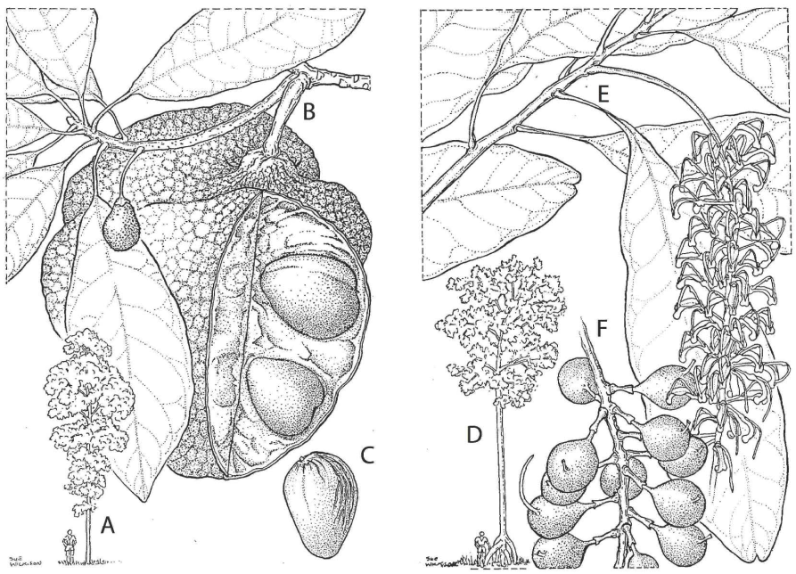

**Figure 11.11:** **Left** *Parartocarpus venenosa*: **A**, young tree; **B**, branch bearing shoot, male flower and edible fruit; **C**, seed. **Right** *Finschia chloroxantha*: **D**, tree with stilt roots; **E**, flowering shoot; **F**, fruit cluster.

Although reflexes of PWOc *lapuka mean ‘breadfruit’ in some languages, the fact that there were at least two other POc terms for breadfruit (ch.9, §4) suggests that the reflexes glossed ‘*Parartocarpus venenosa*’ retain the POc denotation. Kwara’ae *rakʷa-na* is irregular, with initial *r-* for expected †*l-* and suffixed *-na* (medial *-kʷ-* is a regular reflex of *-pʷ-). Araki levu is irregular with *-e-* for †*-a-*.

| **PWOc** |  | *lapuka | ‘k.o. tree with fruit similar to breadfruit, *Parartocarpus venenosa*’ (?) |
| --- | --- | --- | --- |
| NNG | Takia | *lou* | ‘k.o. breadfruit’ |
| NNG | Kaiwa | *lavuk* | ‘breadfruit, *Artocarpus altilis*’ |
| NNG | Medebur | *lapu* | ‘breadfruit, *Artocarpus altilis*’ |
| PT | Are | *napo* | ‘breadfruit’ |
| MM | Notsi | *lipua* | ‘breadfruit’ |
| MM | Sursurunga | *lapu* | ‘tree type whose fruit, similiar to a breadfruit, is yellow and sweet and is eaten raw (possibly Parartocarpus venenonus)’ |
| MM | Patpatar | *lapuo* | ‘*Parartocarpus venenosa*’ |
| MM | Tolai | *lapua* | ‘*Parartocarpus venenosa*’ |

cf. also:

| SES | Kwara’ae | *rakʷa-na* | ‘*Parartocarpus venenosa*’ |
| --- | --- | --- | --- |
| NCV | Araki | *levu* | ‘breadfruit, *Artocarpus altilis*’ |

## Notes

[^1]: Two other nut-bearing species are cultivated in NW Melanesia: *Canarium lamii* along the north coast of New Guinea and the species with the largest trees and largest nuts, *Canarium decumanum*, in the Admiralties (Yen 1996). Their ranges are too narrow for them to be relevant here.
[^2]: Wild specimens with inedible nuts occur westward from Santa Cruz (Yen 1985: 320, Kwa’ioloa & Burt 2001: 104).
[^3]: For example among Takia and Kwara’ae speakers and on Small Malaita the pudding is made with taro (*Colocasia esculenta*), on Ulawa with yams (*Dioscorea esculenta*) (personal observation, Kwa’ioloa & Burt 2001: 102, Ivens 1927: 367-369).
[^4]: According to Record (1945) *Canarium salomonense* is shorter than *Canarium indicum*, around 15 m. tall, but Evans’ (1999: 40) survey of Solomons *Canarium* species found that the two had similar average heights, around 20m, both 7 m taller than *Canarium harveyi*.
[^5]: PCEMP *ka(n,ŋ)aRi is reconstructed on the basis of the Oceanic data here and of Bima *kanari*, Far East Manggarai (Toring) *kenari*, Solorese *kenari* (all CMP) (Verheijen 1990: 197).
[^6]: The Drehet final consonant points to loss of a following vowel. In Mangap a final vowel is regularly assimilated to the penultimate vowel. In Numbami *-a* is added after the reflex of a POc final consonant, and so final *-a* is not diagnostic of a POc final vowel.
[^7]: Reasons for the confusion are (i) that Rotuman *ʔifi* ‘*Inocarpus fagifer*’ has an unexpected initial *ʔ-* (this is probably an outcome of borrowing), and (ii) that Samoan - as a result of regular sound changes - reflects both as *ifi*, and disambiguates them by adding an extra morpheme when the term denotes the ironwood: *ifi-lele* ‘a large timber tree, Intsia sp.’ and *ifi-fatu* ‘a hard-grained *ifi-lele*’ as opposed to *ifi* ‘Inocarpus sp.’. Bwaidoga *ɣ-* reflects an unpredictable accretion.
[^8]: In view of the discussion in this section, a figure showing *Barringtonia novae-hiberniae* would be preferable, but none could be found.
[^9]: Its spread to locations elsewhere in Papua New Guinea is a post-contact phenomenon (R.M. Bourke, pers. comm.).
[^10]: In Kara, Patpatar and Tolai of New Ireland the name of *Barringtonia procera* is a compound (e.g. *paua-hutun* in Patpatar) of the names of *Barringtonia novae-hiberniae* (*paua*) and *Barringtonia asiatica* (*hutun*) (Peekel 1984: 397). Jebb (1992) suggests that this is evidence for a recent introduction of *Barringtonia procera* into the Bismarck Archipelago (he cites Bourke’s research). This is only weak circumstantial evidence, however, as a glance through Peekel shows that such compound plant names are common, and Evans (1999) reports that such a compound is used in S Malaitan to denote *Barringtonia edulis* because the nut is eaten but fish poison is extracted from the bark.
[^11]: Predictably, *kubar* means ‘red’. However, *pala* means ‘coconut husk’, perhaps alluding to the green pericarp of an unhusked young coconut. However, this term does not reflect either of the POc terms reconstructed for ‘coconut husk’ (ch.12, §4.4.)
[^12]: In Hiri Motu, the lingua franca of parts of southern Papua New Guinea, the term *okari* denotes *Terminalia kaernbachii*; in Tok Pisin it denotes *Terminalia impediens*, cultivated on the coasts of the Madang, East Sepik and Sandaun Provinces of mainland Papua New Guinea; (Bourke & Allen forthcoming) .
[^13]: The gloss of the Mwotlap and Mota terms, *Albizia saman*, can be ignored for reconstructive purposes, as the latter is an introduced tree (ch.7, §3.2), and was certainly not a POc denotatum of *tapoRa.
[^14]: This term was recorded only in the inland dialect in which coastal Takia *l* and *r* are merged as *l*, i.e. *tapal* is a regular reflex of *tapoRa.
[^15]: E Fijian *l* usually reflects POc/PEOc *l, but Geraghty (1990) shows that it sometimes reflects *R. Geraghty (2004: 80), however, thinks it is a borrowing from an unidentified Solomons source.
[^16]: There are a number of other *Pandanus* species in New Guinea and the Bismarcks (Kennedy & Clarke 2004), including *P. julianettii*, *P. antarensis* and *P. brosimos*, all with fruit known as *karuka* in Tok Pisin and a major nutritional source in highlands areas, but they do not grow in the lowlands and do not concern us here .
[^17]: Its use elsewhere in the Solomons is unclear because Henderson & Hancock 1988 provide no species identifications for the pandanus types they describe .
[^18]: The reconstruction of PMP *kiRay is supported by the Oceanic data and by Manobo, Tboli (both Philippines) *kilay* ‘*Pandanus* sp.’ (Madulid 2001a: 373).
[^19]: Henderson & Hancock (1988) do not identify the species of the right-hand drawing in Figure 11.5, but comparison with Barrau’s (1962: 160) picture of *Pandanus tectorius* confirms its identification.
[^20]: It is possible that Far East Manggarai *wako*, Ngadlha *waku* ‘broad-leafed *Pandanus* sp.’ and their cognates listed by Verheijen (1990: 232) are cognate with POc *pakum. If so, it is a PCEMP etymon.
[^21]: Blust (1996b) cites the Admiralties forms as representing a PAdm lexical innovation, but the Mapos Buang and Arosi forms in this set show that the form is reconstructable to POc. In Ross (1996d) I reconstructed this form as *mʷaŋa on the basis of the forms listed under ‘cf. also’ below: this was perhaps an error, but see the discussion in the text.
[^22]: Kosirava (coastal) dialect.
[^23]: The spelling *nə-vha-vha* represents an attempt to interpret Wheatley’s (1992) *nawhawha* and is not necessarily accurate.
[^24]: Barrau (1962: 179) suggests that one edible citrus species, *Citrus* macroptera, is indigenous to Melanesia, but there is no clear evidence of this. May (1984: 79) applies the term *Citrus* papuana to the green-skinned bush orange, but this name properly applies as a synonym to the almost inedible *Citrus* hystrix, whilst the green-skinned bush orange is *Citrus* sinensis, which, as its name implies, is an import to Melanesia (French 1986:226,231).
[^25]: It is not mentioned by Peekel (1984).
[^26]: Note that Garuga (ch.7, §4.8) is said to resemble *Spondias cytherea*. See PNCV *mal-mali below.
[^27]: Despite its name, *Ximenia americana* has an African origin.
[^28]: *S. gomata* is not listed in IPNI or APNI. The species label gomata appears to reflect Tolai *gamata* ‘*Syzygium* malaccense’, and *S. gomata* is perhaps a variety thereof.